# Green Bubbles: A Four-Stage Paradigm for Detection and Propagation

Gian Luca Vriz, Luigi Grossi

2024-03-27

# Libraries

The following chunks are related to the article *Green Bubbles: A Four-Stage Paradigm for Detection and Propagation*. The project includes the following libraries.

```r
library(exuber)
library(readr)
library(bsts)
library(dplyr)
library(pscl)
library(car)
library(DescTools)
library(ModelMetrics)
library(fDMA)
library(hrbrthemes)
library(ggpmisc)
library(Rlibeemd)
library(xtable)
library(lmtest)
library(Metrics)
library(tseries)
library(urca)
library(vars)
library(factoextra)
library(ggfortify)
library(modelr)
library(readxl)
library(epiDisplay)
library(blorr)
library(gridExtra)
library(oddsratio)
library(tictoc)
library(Rbeast)
library(bbdetection)
library(devtools)
library(rbmi)
```

```r
library(dplyr)
library(ggplot2)
library(ghyp)
library(lubridate)
library(strucchange)
library(changepoint)
library(Rssa)
library(tidyr)
library(qcc)
library(corrplot)
library(zoo)
library(rugarch)
library(cpm)
library(visreg)
library(urca)
library(glmnet)
library(psych)
```

# Data generation Process and simulations

Firstly, the data generation of bubbles phenomena is outlined.

Three different bubble patterns are being considered.

Below is a graphical representation of potential patterns of bubble collapse as reported in Phillips and Shi (2018).

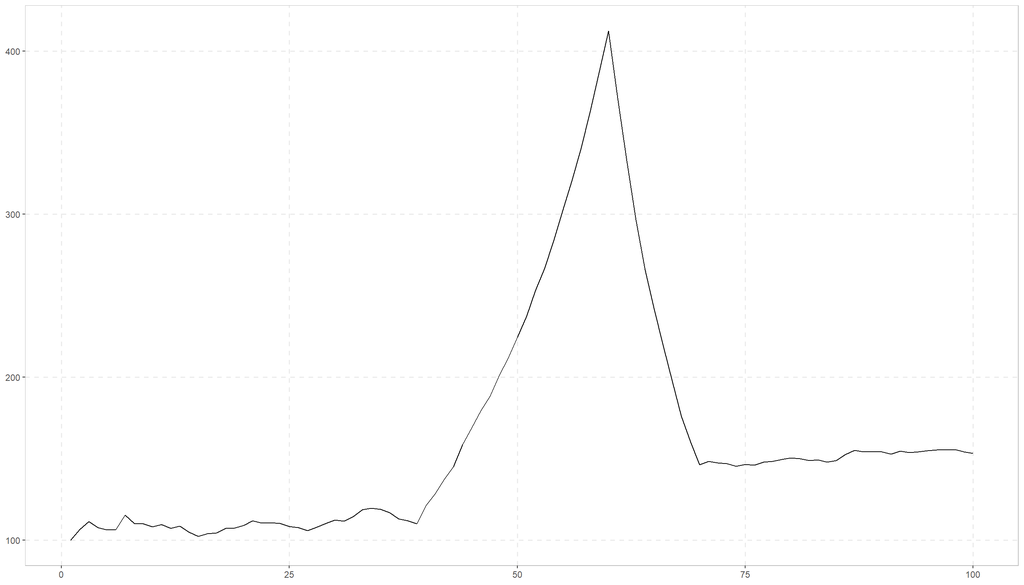

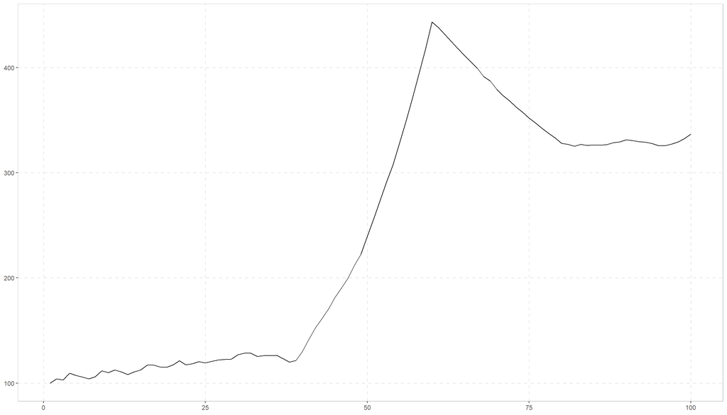

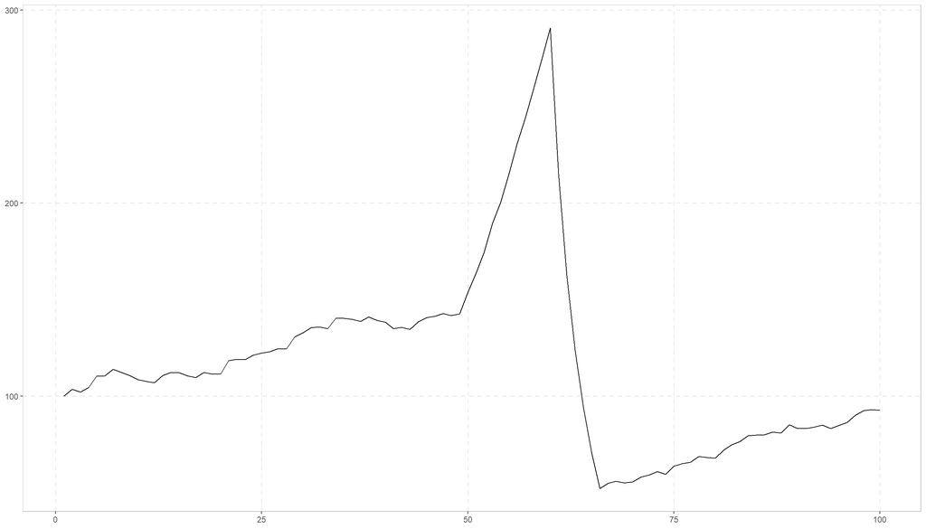

The BSADF (Back Sup-ADF) is compared with the Kolmogorov-Smirnov Change Point Detection Model (KS-CPM). The disturbing path is initially examined, followed by 1000 simulations.

Below, the simulation results are summarized, taking into account both the frequency of correct bubble identifications and the Root Mean Square Error (RMSE).

```r
#Correctness KS-CPM
matrix_test = matrix(ncol = 3, nrow = correct)
matrix_ADF = matrix(ncol = 3, nrow = correct_ADF)
for (i in 1:correct) {
  matrix_test[i, ] <-
    c(results_DIS[lengths(results_DIS) == 3][[i]][1], results_DIS[lengths(results_DIS) == 3] [[i]][2], results_DIS[lengths(results_DIS) == 3][[i]][3])
}
dim(matrix_test)[1]
```

```
## [1] 914
```

```r
#Correctness BSADF test
for (i in 1:correct_ADF) {
  matrix_ADF[i, ] <-
    c(as.numeric(substr(ADF_DIS[lengths(ADF_DIS) == 3][[i]][1], 1, 2)),
      as.numeric(substr(ADF_DIS[lengths(ADF_DIS) == 3][[i]][2], 1, 2)),
      as.numeric(substr(ADF_DIS[lengths(ADF_DIS) == 3][[i]][3], 1, 2)))
}
dim(matrix_ADF)[1]
```

```
## [1] 843
```

```r
#RMSE KS-CPM
Metrics::rmse(c(matrix_test[, 1], matrix_test[, 2], matrix_test[, 3]),
              c(rep(40, correct), rep(60, correct), rep(70, correct)))
```

```
## [1] 1.761386
```

```r
#RMSE BSADF test
Metrics::rmse(c(matrix_ADF[, 1], matrix_ADF[, 2], matrix_ADF[, 3]), c(
  rep(40, correct_ADF),
  rep(60, correct_ADF),
  rep(70, correct_ADF)
))
```

```
## [1] 4.678134
```

```r
#914
#843
```

The same analysis is conducted for the abrupt path.

```r
#Correctness KS-CPM
matrix_test = matrix(ncol = 3, nrow = correct)
matrix_ADF = matrix(ncol = 3, nrow = correct_ADF)
for (i in 1:correct) {
  matrix_test[i, ] <-
    c(results_SUD[lengths(results_SUD) == 3][[i]][1], results_SUD[lengths(results_SUD) == 3] [[i]][2], results_SUD[lengths(results_SUD) == 3] [[i]][3])
}
dim(matrix_test)[1]
```

```
## [1] 844
```

```r
#Correctness BSADF test
for (i in 1:correct_ADF) {
  matrix_ADF[i, ] <-
    c(as.numeric(substr(ADF_SUD[lengths(ADF_SUD) == 3][[i]][1], 1, 2)),
      as.numeric(substr(ADF_SUD[lengths(ADF_SUD) == 3][[i]][2], 1, 2)),
      as.numeric(substr(ADF_SUD[lengths(ADF_SUD) == 3][[i]][3], 1, 2)))
}
dim(matrix_ADF)[1]
```

```
## [1] 543
```

```r
#RMSE KS-CPM
Metrics::rmse(c(matrix_test[, 1], matrix_test[, 2], matrix_test[, 3]),
              c(rep(50, correct), rep(60, correct), rep(66, correct)))
```

```
## [1] 2.189574
```

```r
#RMSE BSADF test
Metrics::rmse(c(matrix_ADF[, 1], matrix_ADF[, 2], matrix_ADF[, 3]), c(
  rep(50, correct_ADF),
  rep(60, correct_ADF),
  rep(66, correct_ADF)
))
```

```
## [1] 3.165285
```

```r
#844
#543
```

Finally, the analysis is extended to include the smoothing path as well.

```r
#Correctness KS-CPM
matrix_test = matrix(ncol = 3, nrow = correct)
matrix_ADF = matrix(ncol = 3, nrow = correct_ADF)
for (i in 1:correct) {
  matrix_test[i, ] <-
    c(results_SMO[lengths(results_SMO) == 3][[i]][1], results_SMO[lengths(results_SMO) == 3] [[i]][2], results_SMO[lengths(results_SMO) == 3] [[i]][3])
}
dim(matrix_test)[1]
```

```
## [1] 894
```

```r
#Correctness BSADF test
for (i in 1:correct_ADF) {
  matrix_ADF[i, ] <-
    c(as.numeric(substr(ADF_SMO[lengths(ADF_SMO) == 3][[i]][1], 1, 2)),
      as.numeric(substr(ADF_SMO[lengths(ADF_SMO) == 3][[i]][2], 1, 2)),
      as.numeric(substr(ADF_SMO[lengths(ADF_SMO) == 3][[i]][3], 1, 2)))
}
dim(matrix_ADF)[1]
```

```
## [1] 816
```

```r
#RMSE KS-CPM
Metrics::rmse(c(matrix_test[, 1], matrix_test[, 2], matrix_test[, 3]),
              c(rep(40, correct), rep(60, correct), rep(80, correct)))
```

```
## [1] 2.066566
```

```r
#RMSE BSADF test
Metrics::rmse(c(matrix_ADF[, 1], matrix_ADF[, 2], matrix_ADF[, 3]), c(
  rep(40, correct_ADF),
  rep(60, correct_ADF),
  rep(80, correct_ADF)
))
```

```
## [1] 6.393739
```

```r
#894
#816
```

The simulation study indicates evidence of the change point detection model outperforming the BSADF test. Attention can now be shifted to real data analysis.

# Detection phase

For the empirical analysis, the Renixx index is chosen to transition to the real data example.

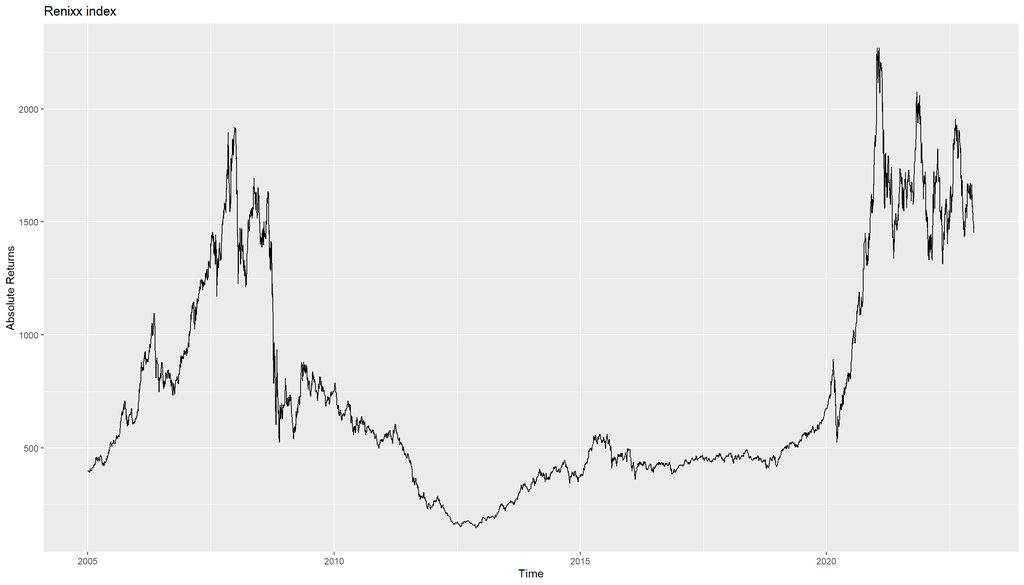

```r
#Updating of the data.
renixx <- read.csv("Economic variables/Renixx.csv")
#Descriptive statistics
renixx$date <- ymd(renixx$date)
renixx <- renixx[order(renixx$date), ]
rownames(renixx) <- NULL
renixx <- renixx[256:dim(renixx)[1], ] #2005/01/01
ggplot(renixx, aes(date, close)) + geom_line() + ggtitle('Renixx index') +
  xlab('Time') + ylab('Absolute Returns')
```

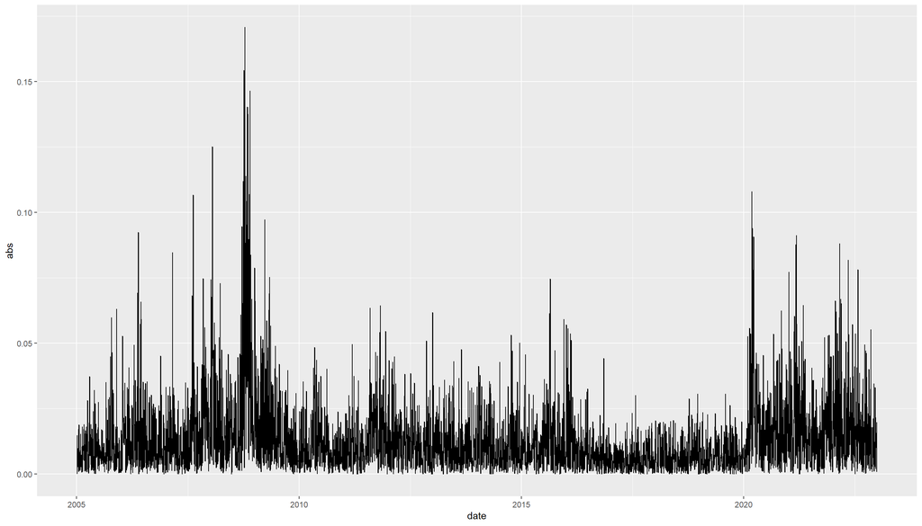

```r
#Log-returns
renixx$date <- ymd(renixx$date)
df <- renixx %>% dplyr::select(1, 3)
rownames(df) <- NULL
df$abs <- abs(c(0, diff(log(df$close))))
#Absolute log-returns
df$rate <- c(0, diff(log(df$close)))
ggplot(df, aes(date, abs)) + geom_line()
```

The empirical analysis is conducted at the monthly frequency.

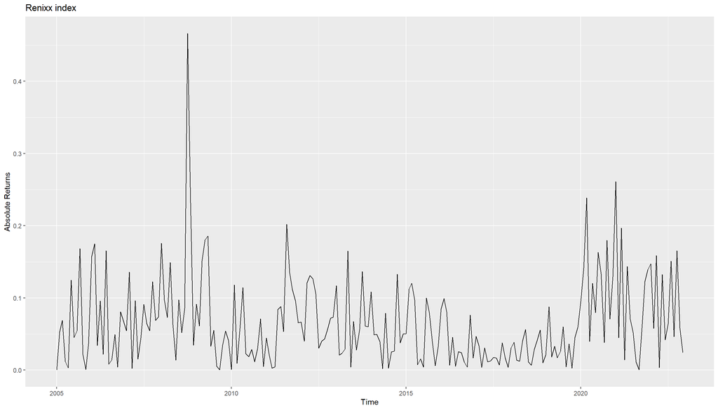

```r
Month <- as.Date(cut(df$date, "month"))
renixx_m <- aggregate(close ~ Month, df, mean)
#Log-returns
renixx_m$Renixx <- c(0, diff(log(renixx_m$close)))
#Absolute log-returns
renixx_m$abs <- c(0, abs(diff(log(renixx_m$close))))
#Standardized values
renixx_m$St <- log(renixx_m$close)
ggplot(renixx_m, aes(Month, abs)) + geom_line() + xlab('Time') + ylab('Absolute Returns') +
  ggtitle('Renixx index')
```

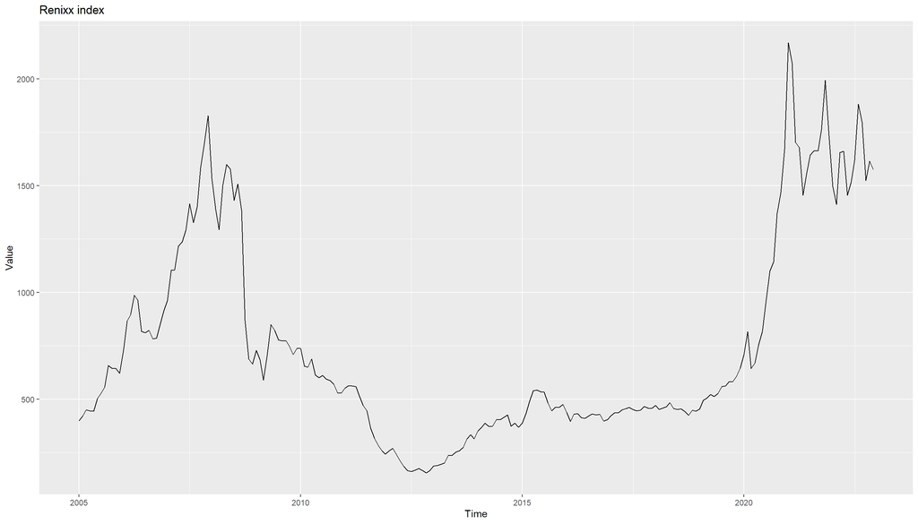

```r
ggplot(renixx_m, aes(Month, close)) + geom_line() + xlab('Time') + ylab('Value') +
  ggtitle('Renixx index')
```

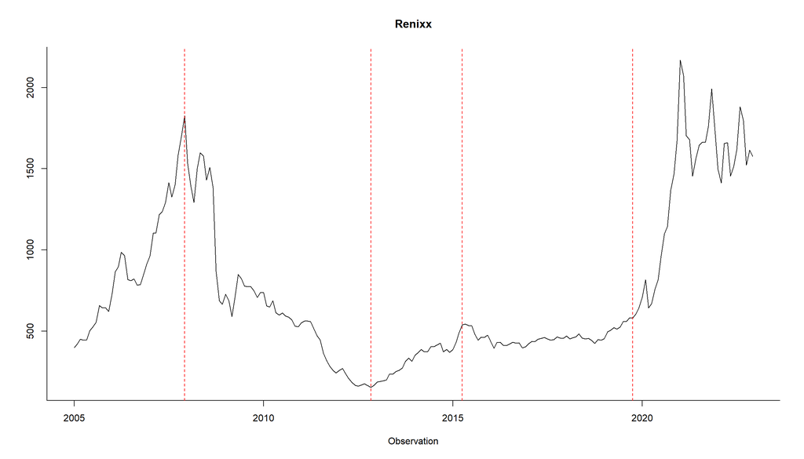

```r
#KS-CPM
test <-
  processStream(
    ts(renixx_m$Renixx, freq = 12, start = decimal_date(ymd("2005-1-1"))),
    "Kolmogorov-Smirnov",
    ARL0 = 500,
    startup = 20
  ) #startup = 20 and ARL0=500 are default values.
breack <- renixx_m$Month[test$changePoints]
plot(
  renixx_m$Month,
  renixx_m$close,
  type = "l",
  xlab = "Observation",
  ylab = "",
  bty = "l",
  main = 'Renixx'
)
abline(v = breack, lty = 2, col = 'red')
```

```r
test
```

```
## $x
##                Jan           Feb           Mar           Apr           May
## 2005  0.0000000000  0.0530189635  0.0687943955 -0.0119283046 -0.0031614423
## 2006  0.1576983710  0.1749323966  0.0341515622  0.0957208036 -0.0217993066
## 2007  0.0545578612  0.1358327830  0.0024174940  0.0961005547  0.0151803929
## 2008 -0.1756064749 -0.0968326005 -0.0728707695  0.1489470465  0.0631577298
## 2009  0.0914962218 -0.0611492288 -0.1513912861  0.1802162711  0.1857942118
## 2010 -0.0009596813 -0.1178961944 -0.0094209776  0.0579208666 -0.1142693067
## 2011  0.0444370211  0.0199152329 -0.0027564990 -0.0046400509 -0.0842015051
## 2012  0.0668437994  0.0400594438 -0.1211641718 -0.1309569248 -0.1264133545
## 2013  0.1169760667  0.0208876124  0.0235850195  0.0289741272  0.1650370226
## 2014  0.1084627881  0.0490217620  0.0496114001 -0.0393263131  0.0018409527
## 2015  0.0505690299  0.1119845016  0.1203081711  0.0974680083  0.0076100111
## 2016 -0.0847890610 -0.0993756016  0.0805477489  0.0068269693 -0.0454210495
## 2017  0.0467343606  0.0335219319 -0.0036486303  0.0306472072  0.0116983857
```

[output cut: 49 more lines]

The previous results are compared with those obtained from the BSADF test.

```
## Using `radf_crit` for `cv`.
```

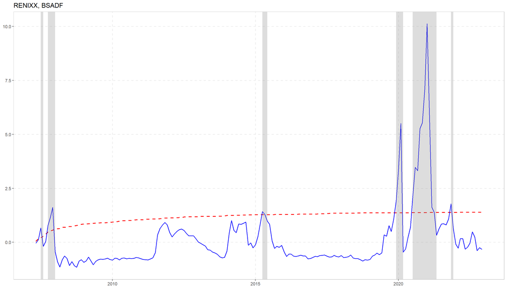

```r
set.seed(123)
series <- ts(renixx_m[, c(2, 4)], frequency = 12, start = c(2005, 1))
results <- radf(series[, 1])
autoplot(results) + labs(title = "RENIXX, BSADF")
```

```r
d_adf <- datestamp(results)
```

```
## Using `radf_crit` for `cv`.
```

```r
d_adf
```

```
##
## ── Datestamp (min_duration = 0) ───────────────────────────────── Monte Carlo ──
##
## series1 :
##        Start       Peak        End Duration   Signal Ongoing
## 1 2007-07-01 2007-07-01 2007-08-01        1 positive   FALSE
## 2 2007-10-01 2007-12-01 2008-01-01        3 positive   FALSE
## 3 2015-04-01 2015-04-01 2015-06-01        2 positive   FALSE
## 4 2019-12-01 2020-02-01 2020-03-01        3 positive   FALSE
## 5 2020-07-01 2021-01-01 2021-05-01       10 positive   FALSE
## 6 2021-11-01 2021-11-01 2021-12-01        1 positive   FALSE
```

There is clear evidence that the BSADF is particularly effective in detecting explosive behaviors, a specific aspect of bubble dynamics. This highlights the need for a more comprehensive tool that encompasses the entire life cycle of a bubble, including its initiation, burst, and conclusion phases.

# Propagation phase

To analyze the green bubbles, various variables will be taken into account. Two main groups stand out: economic/financial variables and Google Trends data.

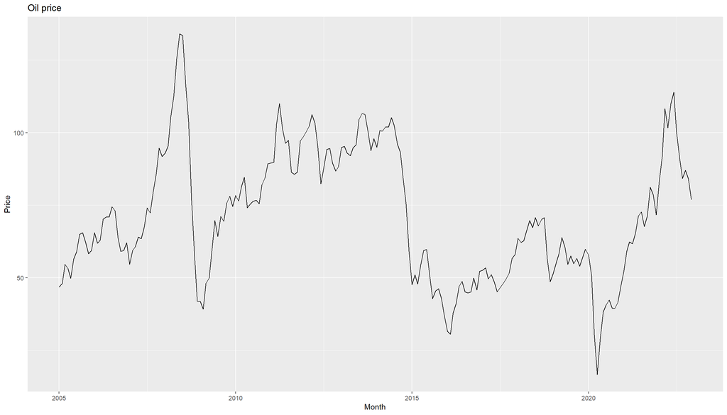

```r
#Oil WTI Futures
Oil <-
  read.csv("Economic variables/Oil_WTI.csv")
Oil$Date <- mdy(Oil$Date)
Month <- as.Date(cut(Oil$Date, "month"))
Oil_m <- aggregate(Price ~ Month, Oil, mean)
#Transformation
Oil_m$Rate_O <- c(0, diff(log(Oil_m$Price)))
Oil_m$Rate_s <- scale(c(0, diff(Oil_m$Price)), scale = TRUE, center = TRUE)
rownames(Oil_m) <- NULL
ggplot(Oil_m, aes(Month, Price)) + geom_line() + ggtitle('Oil price')
```

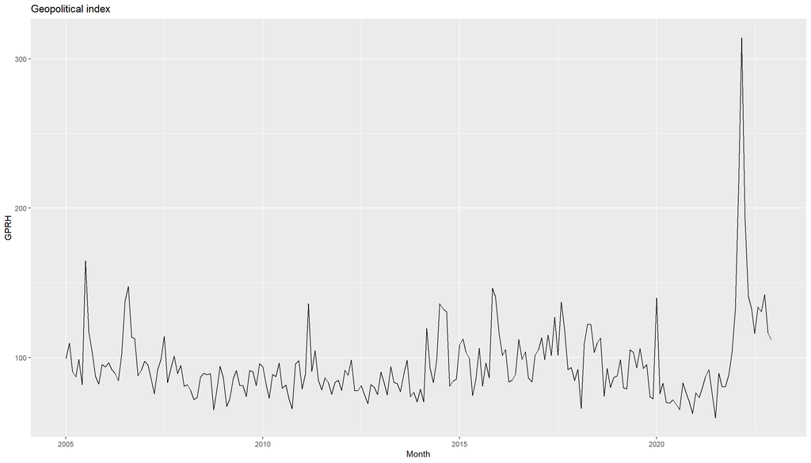

```r
#Geopolitical index
data_gpr_export <-
  read_excel("Economic variables/GPI.xls")
geo_i <- data_gpr_export %>% dplyr::select(6, 3)
colnames(geo_i)[1] <- "Date"
geo_i2 <-
  geo_i[geo_i$Date <= "2022-12-30" &
          geo_i$Date >= "2005-01-01", ] #2005/01/01
Month <- as.Date(cut(geo_i2$Date, "month"))
geo_m <- aggregate(geo_i2$GPRD ~ Month, geo_i2, mean)
colnames(geo_m)[2] <- "GPRH"
geo_m$GPRH <- as.numeric(geo_m$GPRH)
#Transformations
geo_m$Rate_g <- c(0, diff(log(geo_m$GPRH)))
geo_m$St <- scale(c(0, diff(geo_m$GPRH)), scale = TRUE, center = TRUE)
ggplot(geo_m, aes(Month, GPRH)) + geom_line() + ggtitle('Geopolitical index')
```

```r
#MSCI_WORLD
MSCI <- read_csv("Economic variables/MSCI World.csv")
```

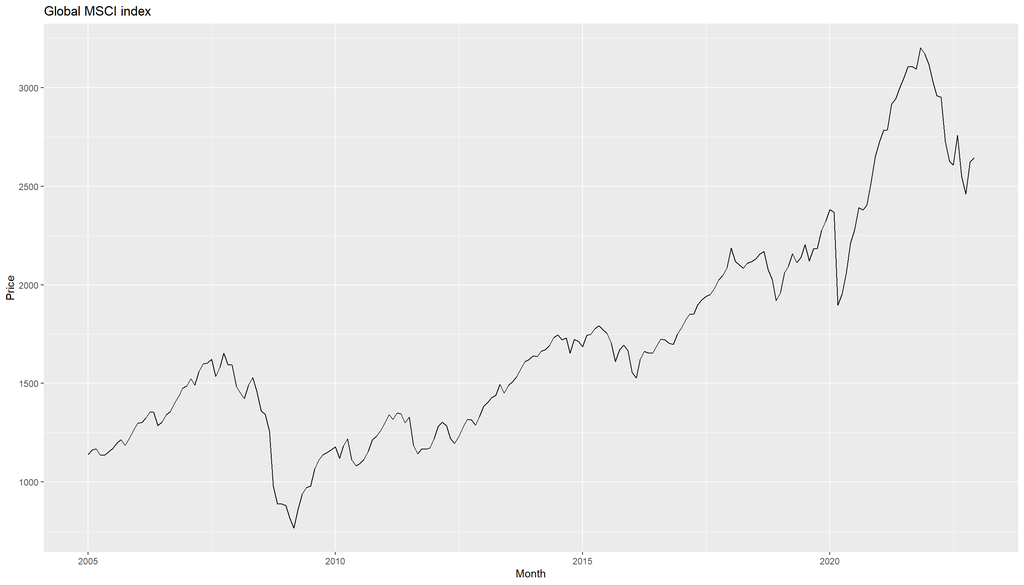

```r
MSCI_2 <- MSCI %>% dplyr::select(6, 2)
MSCI_2$Date <-
  format(as.Date(MSCI_2$Date, format = '%m/%d/%y'), "%m/%d/%Y")
MSCI_2$Date <- mdy(MSCI_2$Date)
Month <- as.Date(cut(MSCI_2$Date, "month"))
MSCI_2$Close <- as.numeric(MSCI_2$Close)
MSCI_m <- aggregate(Close ~ Month, MSCI_2, mean)
colnames(MSCI_m)[2] <- "Price"
MSCI_m$Price <- as.numeric(MSCI_m$Price)
#Transformations
MSCI_m$Rate_ms <- c(0, diff(log(MSCI_m$Price)))
MSCI_m$Rate_s <-
  scale(c(0, diff(MSCI_m$Price)), scale = TRUE, center = TRUE)
ggplot(MSCI_m, aes(Month, Price)) + geom_line() + ggtitle('Global MSCI index')
```

The below chunk illustrates the two bubbles detected by the KS-CPM in the renewable energy market. Additionally, the correlation among these three series will be demonstrated by outlining the oil and MSCI ratio.

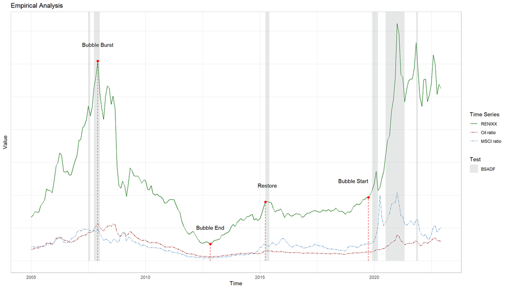

```r
#Ratio
renixx_m$Oil_ratio <- renixx_m$close / Oil_m$Price
renixx_m$MSCI_ratio <- renixx_m$close / MSCI_m$Price
#Final plot for green bubble detection
renixx_m$Date <- as.POSIXct(renixx_m$Month, format = "%Y-%m-%d")
df_rect <-
  data.frame(
    xmin = c(as.POSIXct(d_adf$series1$Start)),
    xmax = c(as.POSIXct(d_adf$series1$End)),
    ymin = 0,
    ymax = Inf,
    Explosive = c("BSADF")
  )
g <- ggplot(renixx_m, aes(x = Date, y = (close / 30))) +
  geom_line(aes(color = "RENIXX")) +
  geom_line(aes(y = MSCI_ratio * 10, color = "Oil ratio"), linetype = "twodash") +
  geom_line(aes(y = Oil_ratio / 2, color = "MSCI ratio"), linetype = "twodash") +
  theme_light() + ylab('Value') + xlab('Time') + ggtitle('Empirical Analysis') +
  theme(plot.title = element_text(hjust = 0.5)) +
  geom_segment(
    aes(
      x = renixx_m$Date[36],
      y = 0,
      xend = renixx_m$Date[36],
      yend = renixx_m$close[36] / 30
    ),
    linetype = "dashed",
    color = "red"
  ) +
  annotate("text",
           x = renixx_m$Date[36],
           y = renixx_m$close[36] / 30 + 5,
           label = "Bubble Burst") +
  geom_segment(
    aes(
      x = renixx_m$Date[95],
      y = 0,
      xend = renixx_m$Date[95],
      yend = renixx_m$close[95] / 30
    ),
    linetype = "dashed",
    color = "red"
  ) +
  annotate("text",
           x = renixx_m$Date[95],
           y = renixx_m$close[95] / 30 + 5,
           label = "Bubble End") +
  geom_segment(
    aes(
      x = renixx_m$Date[124],
      y = 0,
      xend = renixx_m$Date[124],
      yend = renixx_m$close[124] / 30
    ),
    linetype = "dashed",
    color = "red"
  ) +
  annotate("text",
           x = renixx_m$Date[125],
           y = renixx_m$close[124] / 30 + 5,
           label = "Restore") +
  geom_segment(
    aes(
      x = renixx_m$Date[178],
      y = 0,
      xend = renixx_m$Date[178],
      yend = renixx_m$close[178] / 30
    ),
    linetype = "dashed",
    color = "red"
  ) +
  annotate("text",
           x = renixx_m$Date[170],
           y = renixx_m$close[178] / 30 + 5,
           label = "Bubble Start") +
  geom_rect(
    data = df_rect,
    aes(
      xmin = xmin,
      ymin = ymin,
      xmax = xmax,
      ymax = ymax,
      fill = Explosive
    ),
    alpha = 0.2,
    inherit.aes = FALSE
  ) +
  scale_fill_manual(name = 'Test', values = c("azure4")) +
  geom_point(
    data = renixx_m[c(36, 95, 124, 178), ],
    aes(x = Date, y = (close / 30)),
    colour = "red",
    size = 2
  ) +
  scale_color_manual(
    name = 'Time Series',
    breaks = c('RENIXX', 'Oil ratio', 'MSCI ratio'),
    values = c(
      'RENIXX' = 'darkgreen',
      'Oil ratio' = 'darkred',
      'MSCI ratio' = 'steelblue'
    )
  ) +
  theme(
    axis.text.y = element_blank(),
    axis.ticks.y = element_blank(),
    plot.title = element_text(hjust = 0)
  )
grid.arrange(g)
```

Below, the FSI as well as the EPU index are outlined.

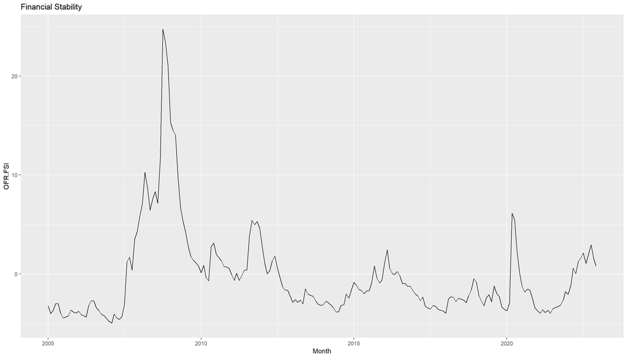

```r
#EPU
GEPUCURRENT <- read.csv("Economic variables/GEPUCURRENT.csv")
GEPUCURRENT$DATE <- ymd(GEPUCURRENT$DATE)
GEPUCURRENT <- GEPUCURRENT[97:312, ] #2005/01/01-2022/12/01
rownames(GEPUCURRENT) <- NULL
#Transformation
GEPUCURRENT$Rate <- c(0, diff(log(GEPUCURRENT$GEPUCURRENT)))
GEPUCURRENT$Rate_s <-
  scale(c(0, diff(GEPUCURRENT$GEPUCURRENT)), scale = TRUE, center = TRUE)
#OFR
Fs <- read.csv("Economic variables/FSI.csv")
Month <- as.Date(cut(ymd(Fs$Date), "month"))
Fs_m <- aggregate(OFR.FSI ~ Month, Fs, mean)
Fs_m <- Fs_m[61:276, ] #2005/01/01-2022/12/01
#Transformation
Fs_m$Rate <- c(0, diff(Fs_m$OFR.FSI))
Fs_m$Rate_s <-
  scale(c(0, diff(Fs_m$OFR.FSI)), scale = TRUE, center = TRUE) #(presence of 0s, no log transformation)
ggplot(Fs_m, aes(Month, OFR.FSI)) + geom_line() + ggtitle('Financial Stability')
```

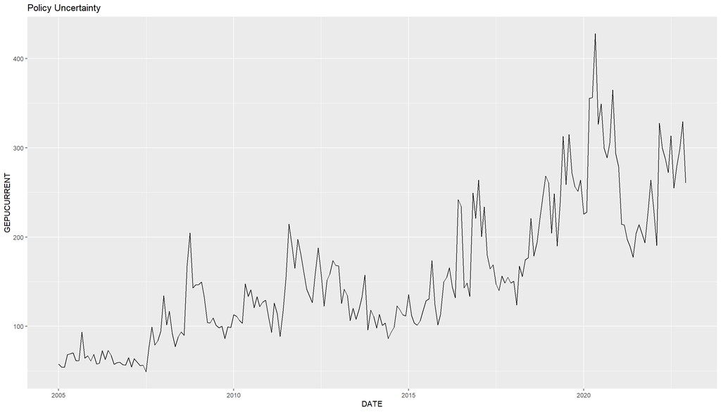

```r
ggplot(GEPUCURRENT, aes(DATE, GEPUCURRENT)) + geom_line() + ggtitle('Policy Uncertainty')
```

Finally, both economic and financial variables are grouped into a single dataset.

[figure not shown]

```r
#Financial/economic variables
Finance <- renixx_m[, c(1, 3)]
colnames(Finance)[2] <- "Renixx"
Finance$Oil_p <- Oil_m$Rate_O
Finance$MSCI <- MSCI_m$Rate_ms
Finance$EPU <- GEPUCURRENT$Rate
Finance$OFR <- Fs_m$Rate
Finance$Geo_i <- geo_m$Rate_g
#Financial dataset
Finance_2 <- renixx_m[, c(1, 2)]
colnames(Finance_2)[2] <- "Renixx"
Finance_2$Renixx <- scale(Finance_2$Renixx, center = TRUE, scale = TRUE)
Finance_2$Oil_p <- scale(Oil_m$Price, center = TRUE, scale = TRUE)
Finance_2$Geo_i <- scale(geo_m$GPRH, center = TRUE, scale = TRUE)
Finance_2$MSCI <- scale(MSCI_m$Price, center = TRUE, scale = TRUE)
Finance_2$EPU <- scale(GEPUCURRENT$GEPUCURRENT, center = TRUE, scale = TRUE)
Finance_2$OFR <- scale(Fs_m$OFR.FSI, center = TRUE, scale = TRUE)
#Plot
ggplot() +
  geom_line(data = Finance_2, aes(x = Month, y = Renixx, color = "Rennix")) +
  geom_line(data = Finance_2, aes(x = Month, y = MSCI, color = "Global MSCI")) +
  geom_line(data = Finance_2, aes(x = Month, y = Geo_i, color = "Geopolitical index")) +
  geom_line(data = Finance_2, aes(x = Month, y = Oil_p, color = "Oil price")) +
  geom_line(data = Finance_2, aes(x = Month, y = EPU, color = "EPU")) +
  geom_line(data = Finance_2, aes(x = Month, y = OFR, color = "OFR")) +
  xlab('data_date') + ggtitle('Financial time series') +
  ylab('Monthly series') + scale_color_manual(
    name = 'Series',
    breaks = c(
      'Rennix',
      'Global MSCI',
      'Geopolitical index',
      'Oil price',
      'EPU',
      'OFR'
    ),
    values = c(
      'Rennix' = 'green',
      'Global MSCI' = 'red',
      'Geopolitical index' = 'blue',
      'Oil price' = 'brown',
      'EPU' = 'orange',
      'OFR' = 'grey'
    )
  )
```

Similarly, the analysis extends to the text variables utilized in the study.

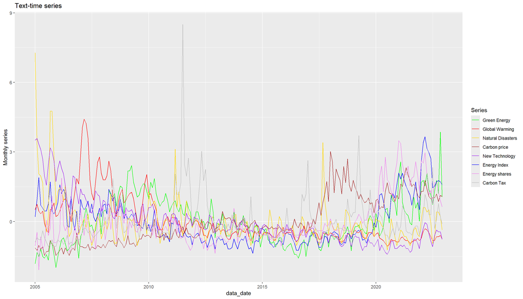

```r
#Green Energy
green_e <-
  read.csv("Google Trends/Green_energy.csv",
           header = TRUE,
           comment.char = "#")[13:228, ] #2005/01/01-2022/12/01
green_e$Time <- ymd(green_e$Time)
green_e$Rate <- c(0, diff(log(green_e$Absolute.Google.Search.Volume)))
Climate <- as.data.frame(green_e[, 1])
colnames(Climate)[1] <- "Date"
Climate$Green_e <- green_e[, 4]
#New technology
Tech_d <-
  read.csv("Google Trends/New_Technology.csv",
           header = TRUE,
           comment.char = "#")[13:228, ] #2005/01/01-2022/12/01
Tech_d$Rate <- c(0, diff(log(Tech_d$Absolute.Google.Search.Volume)))
Climate$Tech <- Tech_d[, 4]
#Energy index
Energy_i <-
  read.csv("Google Trends/Energy_index.csv",
           header = TRUE,
           comment.char = "#")[13:228, ] #2005/01/01-2022/12/01
Energy_i <- Energy_i[, c(1, 2, 3)]
Energy_i$Rate <-
  c(0, diff(log(Energy_i$Absolute.Google.Search.Volume)))
Climate$Energy_i <- Energy_i[, 4]
#Global warming
global_w <-
  read.csv("Google Trends/Global_warming.csv",
           header = TRUE,
           comment.char = "#")[13:228, ] #2005/01/01-2022/12/01
global_w$Rate <-
  c(0, diff(log(global_w$Absolute.Google.Search.Volume)))
Climate$Warming <- global_w[, 4]
#Natural disaster
Natural <-
  read.csv("Google Trends/Natural_disasters.csv",
           header = TRUE,
           comment.char = "#")[13:228, ] #2005/01/01-2022/12/01
Natural$Rate <- c(0, diff(log(Natural$Absolute.Google.Search.Volume)))
Climate$Natural <- Natural[, 4]
#Carbon price
Carbon_p <-
  read.csv("Google Trends/Carbon_price.csv",
           header = TRUE,
           comment.char = "#")[13:228, ] #2005/01/01-2022/12/01
Carbon_p$Rate <-
  c(0, diff(log(Carbon_p$Absolute.Google.Search.Volume)))
Climate$Carbon_p <- Carbon_p[, 4]
#Carbon tax
Tax <-
  read.csv("Google Trends/Carbon_tax.csv",
           header = TRUE,
           comment.char = "#")[13:228, ] #2005/01/01-2022/12/01
Tax$Rate <- c(0, diff(log(Tax$Absolute.Google.Search.Volume)))
Climate$Tax <- Tax[, 4]
#Energy shares
Energy_s <-
  read.csv("Google Trends/Energy_shares.csv",
           header = TRUE,
           comment.char = "#")[13:228, ] #2005/01/01-2022/12/01
Energy_s$Rate <-
  c(0, diff(log(Energy_s$Absolute.Google.Search.Volume)))
Climate$Energy_s <- Energy_s[, 4]
#Text dataset
Climate_2 <- as.data.frame(green_e[, 1])
colnames(Climate_2)[1] <- "Date"
#Scaling
Climate_2$Green_e <-
  scale(as.numeric(green_e[, 3]), center = TRUE, scale = TRUE)
Climate_2$Tech <-
  scale(as.numeric(Tech_d[, 3]), center = TRUE, scale = TRUE)
Climate_2$Warming <-
  scale(as.numeric(global_w[, 3]), center = TRUE, scale = TRUE)
Climate_2$Energy_i <-
  scale(as.numeric(Energy_i[, 3]), center = TRUE, scale = TRUE)
Climate_2$Natural <-
  scale(as.numeric(Natural[, 3]), center = TRUE, scale = TRUE)
Climate_2$Carbon_p <-
  scale(as.numeric(Carbon_p[, 3]), center = TRUE, scale = TRUE)
Climate_2$Energy_s <-
  scale(as.numeric(Energy_s[, 3]), center = TRUE, scale = TRUE)
Climate_2$Energy_T <-
  scale(as.numeric(Energy_s[, 3] + Energy_i[, 3]) / 2,
        center = TRUE,
        scale = TRUE)
Climate_2$Energy_s <-
  scale(as.numeric(Energy_s[, 3]), center = TRUE, scale = TRUE)
Climate_2$Tax <- scale(as.numeric(Tax[, 3]), center = TRUE, scale = TRUE)
#Plot
ggplot() +
  geom_line(data = Climate_2, aes(x = Date, y = Green_e, color = "Green Energy")) +
  geom_line(data = Climate_2, aes(x = Date, y = Energy_i, color = "Energy Index")) +
  geom_line(data = Climate_2, aes(x = Date, y = Warming, color = "Global Warming")) +
  geom_line(data = Climate_2, aes(x = Date, y = Natural, color = "Natural Disasters")) +
  geom_line(data = Climate_2, aes(x = Date, y = Carbon_p, color = "Carbon price")) +
  geom_line(data = Climate_2, aes(x = Date, y = Energy_s, color = "Energy shares")) +
  geom_line(data = Climate_2, aes(x = Date, y = Tax, color = "Carbon Tax")) +
  geom_line(data = Climate_2, aes(x = Date, y = Tech, color = "New Technology")) +
  xlab('data_date') + ggtitle('Text-time series') +
  ylab('Monthly series') + scale_color_manual(
    name = 'Series',
    breaks = c(
      'Green Energy',
      'Global Warming',
      'Natural Disasters',
      'Carbon price',
      "New Technology",
      'Energy Index',
      'Green Bond',
      'Carbon Emissions',
      'Energy shares',
      'Carbon Tax'
    ),
    values = c(
      'Green Energy' = 'green',
      'Global Warming' = 'red',
      'Natural Disasters' = 'gold',
      'Carbon price' = 'brown',
      'New Technology' = 'purple',
      'Energy Index' = 'blue',
      'Carbon Emissions' = 'orange',
      'Energy shares' = 'violet',
      'Carbon Tax' = 'grey'
    )
  )
```

The final dataset is built as below.

```r
#Final dataset (log-diff)
Finance$Merge <- format(as.Date(Finance$Month), "%Y-%m")
Climate$Merge <- format(as.Date(Climate$Date), "%Y-%m")
Data <- merge(Finance, Climate, by = "Merge")
Data <- Data[c(2:216), -c(1, 9)]
rownames(Data) <- NULL
```

```r
#Final dataset (scaled)
Climate_2 <-
  Climate_2[c(
    'Date',
    'Green_e',
    'Tech',
    'Warming',
    'Natural',
    'Carbon_p',
    'Energy_i',
    'Energy_s',
    'Tax'
  )]
Finance_2$Merge <- format(as.Date(Finance_2$Month), "%Y-%m")
Climate_2$Merge <- format(as.Date(Climate_2$Date), "%Y-%m")
#Origianl dataset
Data_or <- merge(Finance_2, Climate_2, by = "Merge")
Data_or <- Data_or[, -c(1, 9)]
rownames(Data_or) <- NULL
```

Before proceeding, both the Augmented Dickey-Fuller (ADF) test and the Kwiatkowski-Phillips-Schmidt-Shin (KPSS) test are conducted to detect the presence of a unit root.

```r
#ADF for text data
summary(ur.df(
  Climate[, "Carbon_p"],
  #lag=12 for seasonality
  type = "drift",
  lags = 12,
  selectlags = "AIC"
))
summary(ur.df(
  Climate[, "Green_e"],
  type = "drift",
  lags = 12,
  selectlags = "AIC"
))
summary(ur.df(
  Climate[, "Tech"],
  type = "drift",
  lags = 12,
  selectlags = "AIC"
))
summary(ur.df(
  Climate[, "Warming"],
  type = "drift",
  lags = 12,
  selectlags = "AIC"
))
summary(ur.df(
  Climate[, "Natural"],
  type = "drift",
  lags = 12,
  selectlags = "AIC"
))
summary(ur.df(
  Climate[3:216, "Tax"],
  type = "drift",
  lags = 12,
  selectlags = "AIC"
))
summary(ur.df(
  Climate[, "Energy_s"],
  type = "drift",
  lags = 12,
  selectlags = "AIC"
))
summary(ur.df(
  Climate[, "Energy_i"],
  type = "drift",
  lags = 12,
  selectlags = "AIC"
))
#ADF for economic data
summary(ur.df(
  Finance[, "Oil_p"],
  type = "drift",
  lags = 12,
  selectlags = "AIC"
))
summary(ur.df(
  Finance[, "Renixx"],
  type = "drift",
  lags = 12,
  selectlags = "AIC"
))
summary(ur.df(
  Finance[3:216, "MSCI"],
  type = "drift",
  lags = 12,
  selectlags = "AIC"
))
summary(ur.df(
  Finance[, "EPU"],
  type = "drift",
  lags = 12,
  selectlags = "AIC"
))
summary(ur.df(
  Finance[3:216, "OFR"],
  type = "drift",
  lags = 12,
  selectlags = "AIC"
))
summary(ur.df(
  Finance[, "Geo_i"],
  type = "drift",
  lags = 12,
  selectlags = "AIC"
))
#KPSS for text data
kpss.test(Climate[, "Carbon_p"])
kpss.test(Climate[, "Tech"])
kpss.test(Climate[, "Natural"])
kpss.test(Climate[, "Green_e"])
kpss.test(Climate[, "Warming"])
kpss.test(Climate[, "Energy_s"])
kpss.test(Climate[, "Tax"])
kpss.test(Climate[, "Energy_i"])
#KPSS for economic data
kpss.test(Finance[, "Oil_p"])
kpss.test(Finance[, "Renixx"])
kpss.test(Finance[, "MSCI"])
kpss.test(Finance[, "Geo_i"])
kpss.test(Finance[, "EPU"])
kpss.test(Finance[, "OFR"])
#Arch test due to no log-transformation
archtest(Finance[, "OFR"])
```

[output not shown]

Propagation effects of both Renixx index and oil prices are evaluated using econometric procedures.

```r
#VAR (12 time frequency of the series)
all_series <-
  ts(
    Data[, c('Renixx', 'OFR', 'Oil_p')],
    start = c(2005, 2),
    end = c(2022, 12),
    frequency = 12
  )
var <-
  VARselect(all_series,
            type = "none",
            lag.max = 12,
            season = 12)
var$selection["FPE(n)"]
```

```
## FPE(n)
##      1
```

```r
var_OFR <- VAR(all_series, 1, season = 12, type = 'none')
summary(var_OFR)
```

```
##
## VAR Estimation Results:
## =========================
## Endogenous variables: Renixx, OFR, Oil_p
## Deterministic variables: none
## Sample size: 214
## Log Likelihood: 96.15
## Roots of the characteristic polynomial:
## 0.384 0.384 0.1224
## Call:
## VAR(y = all_series, p = 1, type = "none", season = 12L)
##
##
## Estimation results for equation Renixx:
## =======================================
## Renixx = Renixx.l1 + OFR.l1 + Oil_p.l1 + sd1 + sd2 + sd3 + sd4 + sd5 + sd6 + sd7 + sd8 + sd9 + sd10 + sd11
##
##            Estimate Std. Error t value Pr(>|t|)
## Renixx.l1  0.265348   0.079867   3.322  0.00106 **
## OFR.l1    -0.003390   0.004664  -0.727  0.46823
## Oil_p.l1   0.050097   0.059826   0.837  0.40337
## sd1       -0.038595   0.029431  -1.311  0.19123
## sd2       -0.061057   0.029056  -2.101  0.03686 *
## sd3       -0.003912   0.029378  -0.133  0.89420
## sd4       -0.058074   0.028973  -2.004  0.04637 *
## sd5       -0.045980   0.029247  -1.572  0.11750
## sd6       -0.026214   0.029140  -0.900  0.36944
## sd7       -0.041228   0.028953  -1.424  0.15601
## sd8       -0.043411   0.028949  -1.500  0.13530
## sd9       -0.067483   0.029013  -2.326  0.02102 *
## sd10      -0.034561   0.029151  -1.186  0.23720
## sd11      -0.037673   0.028886  -1.304  0.19367
## ---
## Signif. codes:  0 '***' 0.001 '**' 0.01 '*' 0.05 '.' 0.1 ' ' 1
##
##
## Residual standard error: 0.08541 on 200 degrees of freedom
## Multiple R-Squared: 0.1468,  Adjusted R-squared: 0.08706
## F-statistic: 2.458 on 14 and 200 DF,  p-value: 0.0032
##
```

[output cut: 54 more lines]

```
## F-statistic: 3.333 on 14 and 200 DF,  p-value: 8.068e-05
##
##
##
## Covariance matrix of residuals:
##           Renixx      OFR     Oil_p
## Renixx  0.007272 -0.07566  0.002594
## OFR    -0.075657  2.29004 -0.055019
## Oil_p   0.002594 -0.05502  0.010568
##
## Correlation matrix of residuals:
##         Renixx     OFR   Oil_p
## Renixx  1.0000 -0.5863  0.2959
## OFR    -0.5863  1.0000 -0.3537
## Oil_p   0.2959 -0.3537  1.0000
```

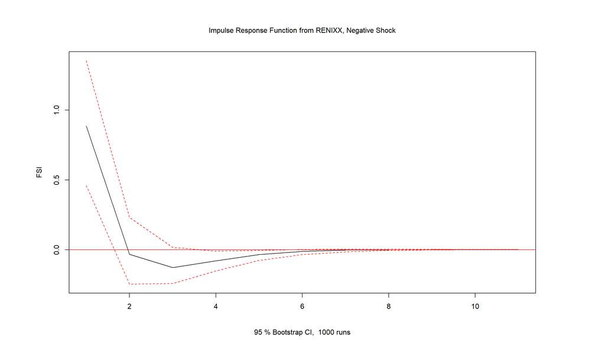

```r
#Impulse Response Function
impresp <- irf(var_OFR,
               impulse = 'Renixx',
               response = 'OFR',
               runs = 1000)
#Negative shock
impresp$irf$Renixx <- -impresp$irf$Renixx
impresp$Lower$Renixx <- -impresp$Lower$Renixx
impresp$Upper$Renixx <- -impresp$Upper$Renixx
plot(impresp, main = 'Impulse Response Function from RENIXX, Negative Shock', ylab =
       'FSI')
```

```r
#OFR
grangertest(OFR ~ Oil_p, order = 12, data = Data)#Granger
```

```
## Granger causality test
##
## Model 1: OFR ~ Lags(OFR, 1:12) + Lags(Oil_p, 1:12)
## Model 2: OFR ~ Lags(OFR, 1:12)
##   Res.Df  Df      F  Pr(>F)
## 1    178
## 2    190 -12 1.9617 0.03021 *
## ---
## Signif. codes:  0 '***' 0.001 '**' 0.01 '*' 0.05 '.' 0.1 ' ' 1
```

```r
grangertest(OFR ~ Renixx, order = 12, data = Data)#Granger
```

```
## Granger causality test
##
## Model 1: OFR ~ Lags(OFR, 1:12) + Lags(Renixx, 1:12)
## Model 2: OFR ~ Lags(OFR, 1:12)
##   Res.Df  Df      F Pr(>F)
## 1    178
## 2    190 -12 1.7868 0.0533 .
## ---
## Signif. codes:  0 '***' 0.001 '**' 0.01 '*' 0.05 '.' 0.1 ' ' 1
```

```r
#Renixx
grangertest(Renixx ~ OFR, order = 12, data = Data)
```

```
## Granger causality test
##
## Model 1: Renixx ~ Lags(Renixx, 1:12) + Lags(OFR, 1:12)
## Model 2: Renixx ~ Lags(Renixx, 1:12)
##   Res.Df  Df      F Pr(>F)
## 1    178
## 2    190 -12 1.0163 0.4358
```

```r
grangertest(Renixx ~ Oil_p, order = 12, data = Data)#Granger
```

```
## Granger causality test
##
## Model 1: Renixx ~ Lags(Renixx, 1:12) + Lags(Oil_p, 1:12)
## Model 2: Renixx ~ Lags(Renixx, 1:12)
##   Res.Df  Df      F  Pr(>F)
## 1    178
## 2    190 -12 2.0724 0.02085 *
## ---
## Signif. codes:  0 '***' 0.001 '**' 0.01 '*' 0.05 '.' 0.1 ' ' 1
```

```r
#Oil price
grangertest(Oil_p ~ OFR, order = 12, data = Data)#Granger
```

```
## Granger causality test
##
## Model 1: Oil_p ~ Lags(Oil_p, 1:12) + Lags(OFR, 1:12)
## Model 2: Oil_p ~ Lags(Oil_p, 1:12)
##   Res.Df  Df      F  Pr(>F)
## 1    178
## 2    190 -12 1.7921 0.05242 .
## ---
## Signif. codes:  0 '***' 0.001 '**' 0.01 '*' 0.05 '.' 0.1 ' ' 1
```

```r
grangertest(Oil_p ~ Renixx, order = 12, data = Data)
```

```
## Granger causality test
##
## Model 1: Oil_p ~ Lags(Oil_p, 1:12) + Lags(Renixx, 1:12)
## Model 2: Oil_p ~ Lags(Oil_p, 1:12)
##   Res.Df  Df      F Pr(>F)
## 1    178
## 2    190 -12 0.7014 0.7488
```

# Forecasting Phase

The following chunks are dedicated to analyzing the dynamics of bubbles in the Renixx index. For this analysis, the following new libraries are required.

```r
library(bestNormalize)
library(caret)
library(Rssa)
library(lattice)
library(fANCOVA)
library(stats)
library(HoRM)
library(parameters)
library(TSA)
library(fGarch)
library(fpp)
library(vars)
library(BVAR)
library(Metrics)
library(aTSA)
library(tsoutliers)
library(tsDyn)
library(goft)
library(bruceR)
```

```r
library(plotmo)
library(grid)
library(factoextra)
library(ggfortify)
library(tvReg)
library(forecast)
```

The plot below illustrates the distribution of text variables based on the three different stages identified by the KS-CPM.

```r
#Codification
breack
```

```
## [1] "2007-12-01" "2012-11-01" "2015-04-01" "2019-10-01"
```

```r
Data_2 <- renixx_m[c(2:216), c('Month', 'close')] #for lagge values
colnames(Data_2)[2] <- "Renixx"
#Dummy codification
Data_2$dummy_Renixx  <- cut(
  Data_2$Month,
  breaks = as.Date(c(
    "2005-01-01", "2012-12-01", "2019-10-01", '2023-01-01'
  )),
  labels = c('Clean-Tech', 'No-bubble', 'Climate')
)
#Dataset lagged values of text variables only (scaled values)
Data_2$dummy_Renixx <- relevel(Data_2$dummy_Renixx, ref = 'No-bubble')
Data_2$Energy_ilag <- lag(Data_or$Energy_i)[2:216]
Data_2$Warminglag <- lag(Data_or$Warming)[2:216]
Data_2$Naturallag <- lag(Data_or$Natural)[2:216]
Data_2$Green_elag <- lag(Data_or$Green_e)[2:216]
Data_2$Carbon_plag <- lag(Data_or$Carbon_p)[2:216]
Data_2$Techlag <- lag(Data_or$Tech)[2:216]
Data_2$Energy_slag <- lag(Data_or$Energy_s)[2:216]
Data_2$Taxlag <- lag(Data_or$Tax)[2:216]
Data_2 <- Data_2[, -c(1, 2)]
rownames(Data_2) <- NULL
#Info
str(Data_2)
```

```
## 'data.frame':    215 obs. of  9 variables:
##  $ dummy_Renixx: Factor w/ 3 levels "No-bubble","Clean-Tech",..: 2 2 2 2 2 2 2 2 2 2 ...
##  $ Energy_ilag : num  0.199 0.954 1.897 0.702 0.576 ...
##  $ Warminglag  : num  0.512 0.745 0.454 0.337 0.454 ...
##  $ Naturallag  : num  7.27 3.31 2.06 1.96 1.67 ...
##  $ Green_elag  : num  -1.82 -1.34 -1.5 -1.18 -1.5 ...
##  $ Carbon_plag : num  -1.13 -1.24 -1.03 -1.19 -1.08 ...
##  $ Techlag     : num  3.5 3.58 3.34 3.1 2.7 ...
##  $ Energy_slag : num  -1.048 -0.464 -2.086 -0.659 -1.178 ...
##  $ Taxlag      : num  -0.882 -0.687 -0.784 -0.784 -0.393 ...
```

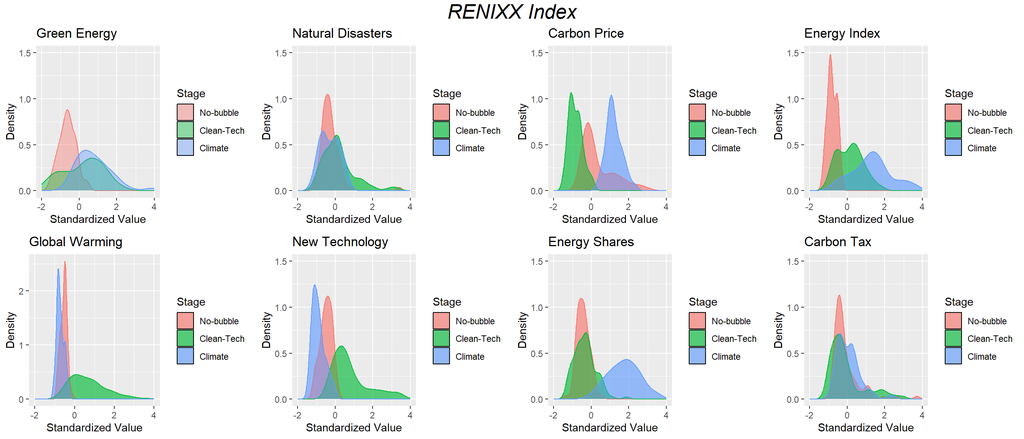

```r
#Density plot for the bubble's stages
p1 <-
  ggplot(
    Data_2,
    aes(
      x = Green_elag,
      group = dummy_Renixx,
      color = dummy_Renixx,
      fill = dummy_Renixx
    )
  ) + labs(fill = 'Stage') +
  guides(color = "none") + geom_density(alpha = 0.4) + ggtitle('Green Energy') + ylab('Density') + xlab('Standardized Value') +
  xlim(c(-2, 4)) + ylim(c(0, 1.5))
p2 <-
  ggplot(
    Data_2,
    aes(
      x = Naturallag,
      group = dummy_Renixx,
      color = dummy_Renixx,
      fill = dummy_Renixx
    )
  ) + geom_density(alpha = 0.4) +
  guides(color = "none") + geom_density(alpha = 0.4) + ggtitle('Natural Disasters') + labs(fill =
                                                                                             'Stage') + ylab('Density') + xlab('Standardized Value') +
  xlim(c(-2, 4)) + ylim(c(0, 1.5))
p3 <-
  ggplot(
    Data_2,
    aes(
      x = Carbon_plag,
      group = dummy_Renixx,
      color = dummy_Renixx,
      fill = dummy_Renixx
    )
  ) + geom_density(alpha = 0.4) + ggtitle('Carbon Price') +
  guides(color = "none") + geom_density(alpha = 0.4) + labs(fill = 'Stage') + xlab('Standardized Value') + ylab('Density') +
  xlim(c(-2, 4)) + ylim(c(0, 1.5))
p4 <-
  ggplot(
    Data_2,
    aes(
      x = Energy_ilag,
      group = dummy_Renixx,
      color = dummy_Renixx,
      fill = dummy_Renixx
    )
  ) + geom_density(alpha = 0.4) +
  guides(color = "none") + geom_density(alpha = 0.4) + xlab('Standardized Value') + ggtitle('Energy Index') + labs(fill =
                                                                                                                     'Stage') + ylab('Density') +
  xlim(c(-2, 4)) + ylim(c(0, 1.5))
p5 <-
  ggplot(
    Data_2,
    aes(
      x = Warminglag,
      group = dummy_Renixx,
      color = dummy_Renixx,
      fill = dummy_Renixx
    )
  ) + geom_density(alpha = 0.4) +
  guides(color = "none") + geom_density(alpha = 0.4) + xlab('Standardized Value') + ggtitle('Global Warming') + labs(fill =
                                                                                                                       'Stage') + ylab('Density') +
  xlim(c(-2, 4)) + ylim(c(0, 2.55))
p6 <-
  ggplot(Data_2,
         aes(
           x = Techlag,
           group = dummy_Renixx,
           color = dummy_Renixx,
           fill = dummy_Renixx
         )) + geom_density(alpha = 0.4) +
  guides(color = "none") + geom_density(alpha = 0.4) + xlab('Standardized Value') +
  ggtitle('New Technology') + labs(fill =
                                     'Stage') + ylab('Density') +
  xlim(c(-2, 4)) + ylim(c(0, 1.5))
p7 <-
  ggplot(
    Data_2,
    aes(
      x = Energy_slag,
      group = dummy_Renixx,
      color = dummy_Renixx,
      fill = dummy_Renixx
    )
  ) + geom_density(alpha = 0.4) +
  guides(color = "none") + geom_density(alpha = 0.4) + xlab('Standardized Value') + ggtitle('Energy Shares') + labs(fill =
                                                                                                                      'Stage') + ylab('Density') +
  xlim(c(-2, 4)) + ylim(c(0, 1.5))
p8 <-
  ggplot(Data_2,
         aes(
           x = Taxlag,
           group = dummy_Renixx,
           color = dummy_Renixx,
           fill = dummy_Renixx
         )) + geom_density(alpha = 0.4) +
  guides(color = "none") + geom_density(alpha = 0.4) + xlab('Standardized Value') + ggtitle('Carbon Tax') + labs(fill =
                                                                                                                   'Stage') + ylab('Density') +
  xlim(c(-2, 4)) + ylim(c(0, 1.5))
grid.arrange(p1,
             p2,
             p3,
             p4,
             p5,
             p6,
             p7,
             p8,
             ncol = 4,
             top = textGrob("RENIXX Index", gp = gpar(fontsize = 20, font = 3)))
```

Here, we utilize both the logit model and the elastic net regularization technique to forecast explosive behaviors within the time series. Economic and text variables, with their first lagged values, are used as potential predictors in the analysis.

```r
#Dummy codification for explosive behaviors
Data_2$dummy_Renixx <-
  as.factor(
    ifelse(
      Data$Month >= "2007-07-01" &
        Data$Month <= "2007-08-01" |
        Data$Month >= "2007-10-01" &
        Data$Month <= "2008-01-01" |
        Data$Month >= "2015-04-01" &
        Data$Month <= "2015-06-01" |
        Data$Month >= "2019-12-01" &
        Data$Month <= "2020-03-01" |
        Data$Month >= "2020-07-01" &
        Data$Month <= "2021-05-01" |
        Data$Month >= "2021-11-01" &
        Data$Month <= "2021-12-01",
      'Explosive',
      'No-Explosive'
    )
  )
#Dataset
Data_2$dummy_Renixx
```

```
##   [1] No-Explosive No-Explosive No-Explosive No-Explosive No-Explosive
##   [6] No-Explosive No-Explosive No-Explosive No-Explosive No-Explosive
##  [11] No-Explosive No-Explosive No-Explosive No-Explosive No-Explosive
##  [16] No-Explosive No-Explosive No-Explosive No-Explosive No-Explosive
##  [21] No-Explosive No-Explosive No-Explosive No-Explosive No-Explosive
##  [26] No-Explosive No-Explosive No-Explosive No-Explosive Explosive
##  [31] Explosive    No-Explosive Explosive    Explosive    Explosive
##  [36] Explosive    No-Explosive No-Explosive No-Explosive No-Explosive
##  [41] No-Explosive No-Explosive No-Explosive No-Explosive No-Explosive
##  [46] No-Explosive No-Explosive No-Explosive No-Explosive No-Explosive
##  [51] No-Explosive No-Explosive No-Explosive No-Explosive No-Explosive
##  [56] No-Explosive No-Explosive No-Explosive No-Explosive No-Explosive
##  [61] No-Explosive No-Explosive No-Explosive No-Explosive No-Explosive
##  [66] No-Explosive No-Explosive No-Explosive No-Explosive No-Explosive
##  [71] No-Explosive No-Explosive No-Explosive No-Explosive No-Explosive
```

[output cut: 29 more lines]

```r
Data_2$dummy_Renixx <-
  relevel(Data_2$dummy_Renixx, ref = 'No-Explosive')
#Economic variables
Data_2$diff_Enii <-
  lag(scale((renixx_m$close), center = TRUE, scale = TRUE))[2:216]
Data_2$MSCIlag <- lag(MSCI_m$Price)[2:216]
Data_2$Oillag <- lag(Oil_m$Price)[2:216]
Data_2$EPUlag <- lag(GEPUCURRENT$GEPUCURRENT)[2:216]
#Data_2$OFRlag<-lag(Fs_m$OFR.FSI)[2:216]
Data_2$GEOlag <- lag(geo_m$GPRH)[2:216]
#Scaling and diff
Data_2$Oillag <-
  scale(c(NA, diff(Data_2$Oillag)), center = TRUE, scale = TRUE)
Data_2$EPUlag <-
  scale(c(NA, diff(Data_2$EPUlag)), center = TRUE, scale = TRUE)
Data_2$MSCIlag <-
  scale(c(NA, diff(Data_2$MSCIlag)), center = TRUE, scale = TRUE)
Data_2$GEOlag <-
  scale(c(NA, diff(Data_2$GEOlag)), center = TRUE, scale = TRUE)
```

Three different generalized linear model are estimated to provide the most accurate prediction of such a phenomena.

- Logit model with only the RENNIX variable at the previous time (naive model).
- Logit model with lagged variables.
- Elastic net regularization logistic model.

```r
#0,1 codification
Data_2$dummy_Renixx <-
  as.factor(
    ifelse(
      Data$Month >= "2007-07-01" &
        Data$Month <= "2007-08-01" |
        Data$Month >= "2007-10-01" &
        Data$Month <= "2008-01-01" |
        Data$Month >= "2015-04-01" &
        Data$Month <= "2015-06-01" |
        Data$Month >= "2019-12-01" &
        Data$Month <= "2020-03-01" |
        Data$Month >= "2020-07-01" &
        Data$Month <= "2021-05-01" |
        Data$Month >= "2021-11-01" & Data$Month <= "2021-12-01",
      1,
      0
    )
  )
#Train/validation splitting (choosen depending on the distribution of explosive events)
train.data  <- Data_2[c(2:190), ] #no first observation for NA
vali.data <- Data_2[c(191:215), ]
#Dummy code categorical predictor variables
x <- model.matrix(dummy_Renixx ~ ., train.data)[, -1]
#Convert the outcome (class) to a numerical variable
y <- train.data$dummy_Renixx
```

```r
#Elastic net CV
#### creating sampling seeds ####
#https://rpubs.com/crossxwill/time-series-cv
set.seed(123)
seeds <- vector(mode = "list", length = 57)
for (i in 1:56)
  seeds[[i]] <- sample.int(1000, 15)
seeds[[57]] <- sample.int(1000, 1)
###
#Hyperparameters's estiamtion
tuneLength.num <- 15
myTimeControl <- trainControl(
  method = "timeslice",
  initialWindow = 122,
  #122 to include the clean tech bubble
  horizon = 12,
  #one year of moving window.
  fixedWindow = FALSE,
  allowParallel = FALSE,
  seeds = seeds
)
glmnet.mod <- train(
  dummy_Renixx ~ .,
  data = train.data,
  method = "glmnet",
  family = "binomial",
  trControl = c(myTimeControl),
  tuneLength = tuneLength.num
)
glmnet.mod
```

```
## glmnet
##
## 189 samples
##  13 predictor
##   2 classes: '0', '1'
##
## No pre-processing
## Resampling: Rolling Forecasting Origin Resampling (12 held-out with no fixed window)
## Summary of sample sizes: 122, 123, 124, 125, 126, 127, ...
## Resampling results across tuning parameters:
##
##   alpha      lambda        Accuracy   Kappa
##   0.1000000  4.271266e-05  0.7336310   0.0033983636
##   0.1000000  7.595505e-05  0.7336310   0.0033983636
##   0.1000000  1.350693e-04  0.7425595   0.0034812505
##   0.1000000  2.401909e-04  0.7604167   0.0044205545
##   0.1000000  4.271266e-04  0.7946429   0.0045339020
##   0.1000000  7.595505e-04  0.8110119   0.0000000000
##   0.1000000  1.350693e-03  0.8467262   0.0000000000
##   0.1000000  2.401909e-03  0.8660714   0.0000000000
##   0.1000000  4.271266e-03  0.9017857   0.0000000000
##   0.1000000  7.595505e-03  0.9107143   0.0000000000
##   0.1000000  1.350693e-02  0.9107143   0.0000000000
##   0.1000000  2.401909e-02  0.9107143   0.0000000000
##   0.1000000  4.271266e-02  0.9107143   0.0000000000
##   0.1000000  7.595505e-02  0.9107143   0.0000000000
##   0.1000000  1.350693e-01  0.9107143   0.0000000000
##   0.1642857  4.271266e-05  0.7247024  -0.0013635412
##   0.1642857  7.595505e-05  0.7261905   0.0004221731
##   0.1642857  1.350693e-04  0.7351190   0.0034812505
##   0.1642857  2.401909e-04  0.7529762   0.0034812505
##   0.1642857  4.271266e-04  0.7901786   0.0045339020
##   0.1642857  7.595505e-04  0.8080357   0.0000000000
##   0.1642857  1.350693e-03  0.8467262   0.0000000000
##   0.1642857  2.401909e-03  0.8660714   0.0000000000
##   0.1642857  4.271266e-03  0.9032738   0.0000000000
##   0.1642857  7.595505e-03  0.9107143   0.0000000000
##   0.1642857  1.350693e-02  0.9107143   0.0000000000
##   0.1642857  2.401909e-02  0.9107143   0.0000000000
##   0.1642857  4.271266e-02  0.9107143   0.0000000000
```

[output cut: 185 more lines]

```
##   1.0000000  2.401909e-04  0.7261905   0.0118167309
##   1.0000000  4.271266e-04  0.7336310   0.0121049439
##   1.0000000  7.595505e-04  0.7500000   0.0174075675
##   1.0000000  1.350693e-03  0.7812500   0.0228905454
##   1.0000000  2.401909e-03  0.8363095   0.0000000000
##   1.0000000  4.271266e-03  0.9077381   0.0000000000
##   1.0000000  7.595505e-03  0.9107143   0.0000000000
##   1.0000000  1.350693e-02  0.9107143   0.0000000000
##   1.0000000  2.401909e-02  0.9107143   0.0000000000
##   1.0000000  4.271266e-02  0.9107143   0.0000000000
##   1.0000000  7.595505e-02  0.9107143   0.0000000000
##   1.0000000  1.350693e-01  0.9107143   0.0000000000
##
## Accuracy was used to select the optimal model using the largest value.
## The final values used for the model were alpha = 0.1 and lambda = 0.1350693.
```

```r
#Fit the final model on the training data
model <-
  glmnet(
    x,
    y,
    alpha = glmnet.mod$bestTune$alpha,
    family = "binomial",
    lambda = glmnet.mod$bestTune$lambda
  )
model_plot <-
  glmnet(x, y, alpha = glmnet.mod$bestTune$alpha, family = "binomial")
#Display regression coefficients
coef(model)
```

```
## 14 x 1 sparse Matrix of class "dgCMatrix"
##                      s0
## (Intercept) -2.12963885
## Energy_ilag  0.07621635
## Warminglag   .
## Naturallag  -0.08123680
## Green_elag   .
## Carbon_plag  0.07989979
## Techlag     -0.14371325
## Energy_slag  0.35131157
## Taxlag      -0.05952806
## diff_Enii    0.61083186
## MSCIlag      0.14099129
## Oillag       0.07662637
## EPUlag      -0.03687397
## GEOlag       .
```

```r
#Make predictions on the test data
x.test <- model.matrix(dummy_Renixx ~ ., vali.data)[, -1]
probabilities <- model %>% predict(newx = x.test)
predicted.classes <- ifelse(probabilities > 0.5, 1, 0)
#Model accuracy
observed.classes <- vali.data$dummy_Renixx
mean(predicted.classes == observed.classes)
```

```
## [1] 0.88
```

```r
confusionMatrix(as.factor(predicted.classes[, 1]), observed.classes)
```

```
## Confusion Matrix and Statistics
##
##           Reference
## Prediction  0  1
##          0 16  2
##          1  1  6
##
##                Accuracy : 0.88
##                  95% CI : (0.6878, 0.9745)
##     No Information Rate : 0.68
##     P-Value [Acc > NIR] : 0.02072
##
##                   Kappa : 0.7148
##
##  Mcnemar's Test P-Value : 1.00000
##
##             Sensitivity : 0.9412
##             Specificity : 0.7500
##          Pos Pred Value : 0.8889
##          Neg Pred Value : 0.8571
##              Prevalence : 0.6800
##          Detection Rate : 0.6400
##    Detection Prevalence : 0.7200
##       Balanced Accuracy : 0.8456
##
##        'Positive' Class : 0
##
```

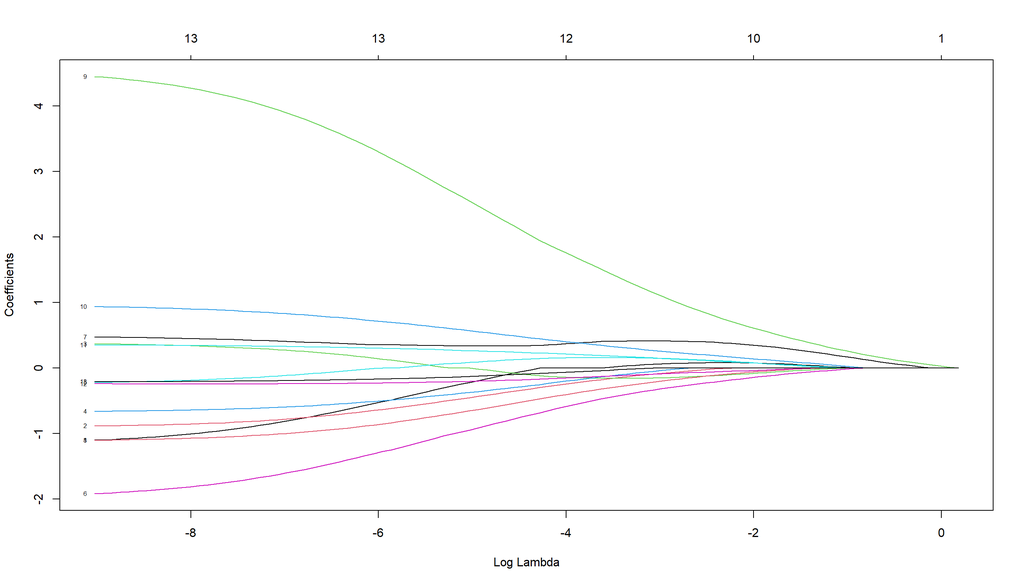

```r
#Plot of the coefficients
plot(model_plot, xvar = "lambda", label = T)
```

```r
lbs_fun <- function(fit, offset_x = 1, ...) {
  L <- length(fit$lambda)
  x <- log(fit$lambda[L]) + offset_x
  y <- fit$beta[, L]
  labs <- names(y)
  text(x, y, labels = labs, ...)
}
```

```r
#Logit model with variables
model_f <-
  glm(dummy_Renixx ~ .,
      family = binomial(link = "logit"),
      data = train.data)
model_0 <-
  glm(dummy_Renixx ~ 1,
      family = binomial(link = "logit"),
      data = train.data)
model_2 <-
  glm(
    dummy_Renixx ~ MSCIlag + diff_Enii + Energy_ilag + Techlag,
    family = binomial(link = "logit"),
    data = train.data
  )
summary(model_2)
```

```
##
## Call:
## glm(formula = dummy_Renixx ~ MSCIlag + diff_Enii + Energy_ilag +
##     Techlag, family = binomial(link = "logit"), data = train.data)
##
## Coefficients:
##             Estimate Std. Error z value Pr(>|z|)
## (Intercept)  -3.5995     0.6624  -5.434  5.5e-08 ***
## MSCIlag       1.2173     0.5035   2.418 0.015611 *
## diff_Enii     4.0071     1.0524   3.808 0.000140 ***
## Energy_ilag  -1.5379     0.9178  -1.676 0.093820 .
## Techlag      -2.4478     0.7377  -3.318 0.000907 ***
## ---
## Signif. codes:  0 '***' 0.001 '**' 0.01 '*' 0.05 '.' 0.1 ' ' 1
##
## (Dispersion parameter for binomial family taken to be 1)
##
##     Null deviance: 118.878  on 188  degrees of freedom
## Residual deviance:  62.654  on 184  degrees of freedom
## AIC: 72.654
##
## Number of Fisher Scoring iterations: 8
```

```r
model_2$deviance
```

```
## [1] 62.65406
```

```r
- 2 * logLik(model_2)
```

```
## 'log Lik.' 62.65406 (df=5)
```

```r
#Check
vif(model_2) #>10 multicollinearity
```

```
##     MSCIlag   diff_Enii Energy_ilag     Techlag
##    1.301439    8.510276    4.476498    2.900628
```

```r
lrtest(model_0, model_2) #reject null hypothesis -> complex model
```

```
## Likelihood ratio test for MLE method
## Chi-squared 4 d.f. =  56.22399 , P value =  1.799646e-11
```

```r
lrtest(model_2, model_f) #accept null hypothesis -> nested model
```

```
## Likelihood ratio test for MLE method
## Chi-squared 9 d.f. =  7.198425 , P value =  0.6164689
```

```r
blr_linktest(model_2) #misspecification -> no
```

```
##
## Call:
## glm(formula = resp ~ fit + fit2, family = binomial(link = "logit"),
##     data = newdat)
##
## Coefficients:
##              Estimate Std. Error z value Pr(>|z|)
## (Intercept) -0.005425   0.450900  -0.012  0.99040
## fit          1.084131   0.334573   3.240  0.00119 **
## fit2         0.027005   0.076403   0.353  0.72374
## ---
## Signif. codes:  0 '***' 0.001 '**' 0.01 '*' 0.05 '.' 0.1 ' ' 1
##
## (Dispersion parameter for binomial family taken to be 1)
##
##     Null deviance: 118.878  on 188  degrees of freedom
## Residual deviance:  62.538  on 186  degrees of freedom
## AIC: 68.538
##
## Number of Fisher Scoring iterations: 10
```

```r
#R^2
list(model = pscl::pR2(model_2)["McFadden"])
```

```
## fitting null model for pseudo-r2
```

```
## $model
##  McFadden
## 0.4729552
```

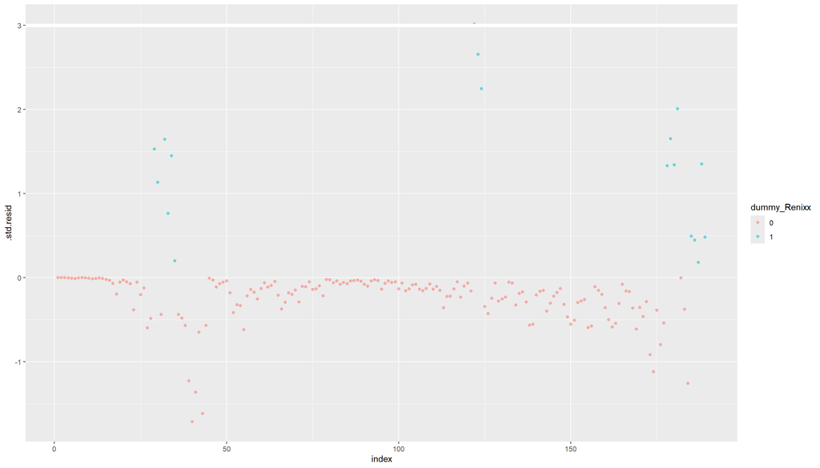

```r
#Plot
model1_data <- augment(model_2) %>% mutate(index = 1:n())
ggplot(model1_data, aes(index, .std.resid, color = dummy_Renixx)) +
  geom_point(alpha = .5) +
  geom_ref_line(h = 3)
```

```r
#Odds ratio with 0.1
or_glm(
  data = train.data,
  model = model_2,
  incr = c(
    Naturallag = 0.1,
    Green_elag = 0.1,
    Energy_ilag = 0.1,
    Techlag = 0.1,
    Carbon_plag = 0.1,
    Warminglag = 0.1,
    Energy_slag = 0.1,
    Taxlag = 0.1,
    MSCIlag = 0.1,
    diff_Enii = 0.1,
    Time = 0.1,
    OFRlag = 0.1
  )
)
```

```
##     predictor oddsratio ci_low (2.5) ci_high (97.5) increment
## 1     MSCIlag     1.129        1.032          1.260       0.1
## 2   diff_Enii     1.493        1.250          1.896       0.1
## 3 Energy_ilag     0.857        0.703          1.011       0.1
## 4     Techlag     0.783        0.664          0.890       0.1
```

```r
#Validation set
predictions <-
  predict(model_2, type = "response", newdata = vali.data)
predictions
```

```
##         191         192         193         194         195         196
## 0.996633260 0.998889276 0.999881670 0.999710023 0.978344140 0.998027008
##         197         198         199         200         201         202
## 0.962436713 0.993205522 0.997880572 0.999085848 0.983877821 0.978930174
##         203         204         205         206         207         208
## 0.999925641 0.997792870 0.292740550 0.013539580 0.056830318 0.333724339
##         209         210         211         212         213         214
## 0.006478099 0.243186964 0.976084778 0.999513335 0.409748006 0.408294246
##         215
## 0.992767234
```

```r
threshold <- 0.5
binary_predictions <- ifelse(predictions > threshold, 1, 0)
confusionMatrix(as.factor(binary_predictions), observed.classes)
```

```
## Confusion Matrix and Statistics
##
##           Reference
## Prediction 0 1
##          0 8 0
##          1 9 8
##
##                Accuracy : 0.64
##                  95% CI : (0.4252, 0.8203)
##     No Information Rate : 0.68
##     P-Value [Acc > NIR] : 0.744512
##
##                   Kappa : 0.3626
##
##  Mcnemar's Test P-Value : 0.007661
##
##             Sensitivity : 0.4706
##             Specificity : 1.0000
##          Pos Pred Value : 1.0000
##          Neg Pred Value : 0.4706
##              Prevalence : 0.6800
##          Detection Rate : 0.3200
##    Detection Prevalence : 0.3200
##       Balanced Accuracy : 0.7353
##
##        'Positive' Class : 0
##
```

```r
#Logit model with only the RENIXX index.
model_3 <-
  glm(dummy_Renixx ~ diff_Enii,
      family = binomial(link = "logit"),
      data = train.data)
summary(model_3)
```

```
##
## Call:
## glm(formula = dummy_Renixx ~ diff_Enii, family = binomial(link = "logit"),
##     data = train.data)
##
## Coefficients:
##             Estimate Std. Error z value Pr(>|z|)
## (Intercept)  -2.3553     0.2985  -7.892 2.99e-15 ***
## diff_Enii     1.4362     0.3033   4.736 2.18e-06 ***
## ---
## Signif. codes:  0 '***' 0.001 '**' 0.01 '*' 0.05 '.' 0.1 ' ' 1
##
## (Dispersion parameter for binomial family taken to be 1)
##
##     Null deviance: 118.878  on 188  degrees of freedom
## Residual deviance:  94.367  on 187  degrees of freedom
## AIC: 98.367
##
## Number of Fisher Scoring iterations: 6
```

```r
#Validation set
predictions <-
  predict(model_3, type = "response", newdata = vali.data)
predictions
```

```
##       191       192       193       194       195       196       197       198
## 0.4566274 0.6065513 0.8730450 0.8378355 0.6295240 0.6125124 0.4460872 0.5256419
##       199       200       201       202       203       204       205       206
## 0.5869256 0.6001936 0.6008466 0.6700365 0.8020310 0.6508291 0.4774219 0.4152799
##       207       208       209       210       211       212       213       214
## 0.5953144 0.5995888 0.4466965 0.4933169 0.5680377 0.7436898 0.6921725 0.4972678
##       215
## 0.5654314
```

```r
threshold <- 0.5
binary_predictions <- ifelse(predictions > threshold, 1, 0)
confusionMatrix(as.factor(binary_predictions), observed.classes)
```

```
## Confusion Matrix and Statistics
##
##           Reference
## Prediction  0  1
##          0  6  1
##          1 11  7
##
##                Accuracy : 0.52
##                  95% CI : (0.3131, 0.722)
##     No Information Rate : 0.68
##     P-Value [Acc > NIR] : 0.970064
##
##                   Kappa : 0.1713
##
##  Mcnemar's Test P-Value : 0.009375
##
##             Sensitivity : 0.3529
##             Specificity : 0.8750
##          Pos Pred Value : 0.8571
##          Neg Pred Value : 0.3889
##              Prevalence : 0.6800
##          Detection Rate : 0.2400
##    Detection Prevalence : 0.2800
##       Balanced Accuracy : 0.6140
##
##        'Positive' Class : 0
##
```

As indicated by the above results, the elastic net regularization model demonstrates superior forecasting performance compared to other models.

Because of the escalating utilization of Google throughout the years, the chosen time frame extends from 2015 to 2022. This decision aims to capture a heightened correlation between text variables and the Renixx index, as depicted in the above plot. In the one-step ahead exercise, four models are taken into account.

*ARIMA

*ARIMAX

*VECM

*BSTS

```r
#Google trends
Green_energy_pred <-
  read.csv("Google Trends/Green_energy.csv",
           header = TRUE,
           comment.char = "#")
Carbon_tax_pred <-
  read.csv("Google Trends/Carbon_tax.csv",
           header = TRUE,
           comment.char = "#")
Carbon_price_pred <-
  read.csv("Google Trends/Carbon_price.csv",
           header = TRUE,
           comment.char = "#")
Natural_disaster_pred <-
  read.csv("Google Trends/Natural_disasters.csv",
           header = TRUE,
           comment.char = "#")
Global_warming_pred <-
  read.csv("Google Trends/Global_warming.csv",
           header = TRUE,
           comment.char = "#")
New_tech_pred <-
  read.csv("Google Trends/New_Technology.csv",
           header = TRUE,
           comment.char = "#")
Energy_spred <-
  read.csv("Google Trends/Energy_shares.csv",
           header = TRUE,
           comment.char = "#")
Energy_ipred <-
  read.csv("Google Trends/Energy_index.csv",
           header = TRUE,
           comment.char = "#")
#Oil price
Oil_pred <-
  read.csv("Data forecasting/Oil_pred.csv",
           header = TRUE,
           comment.char = "#")
Oil_pred$Date <- dmy(Oil_pred$Date)
Month <- as.Date(cut(Oil_pred$Date, "month"))
Oil_predm <- aggregate(Price ~ Month, Oil_pred, mean)
Oil_predm <- Oil_predm[217:228, ] #2005/01/01 2023/12/01
Oil_predm <- rbind(Oil_m[, 1:2], Oil_predm)
#MSCI
MSCI_pred <-
  read.csv("Data forecasting/MSCI World_pred.csv",
           header = TRUE,
           comment.char = "#")
MSCI_pred$Date <- dmy(MSCI_pred$Date)
MSCI_pred$Price <- as.numeric(gsub(",", "", MSCI_pred$Price))
Month <- as.Date(cut(MSCI_pred$Date, "month"))
MSCI_predm <- aggregate(Price ~ Month, MSCI_pred, mean)
MSCI_predm <- MSCI_predm[127:138, ] #2005/01/01 2023/12/01
MSCI_predm <- rbind(MSCI_m[, 1:2], MSCI_predm)
#GEPUCURRENT
GEPUCURRENT_pred <-
  read.csv(
    "Data forecasting/GEPUCURRENT_pred.csv",
    header = TRUE,
    comment.char = "#"
  )
GEPUCURRENT_pred$DATE <- ymd(GEPUCURRENT_pred$DATE)
GEPUCURRENT_pred <- GEPUCURRENT_pred[217:228, ]
GEPUCURRENT_pred <- rbind(GEPUCURRENT[, 1:2], GEPUCURRENT_pred)
#Geopolitical index
data_gpr_pred <- read_excel("Data forecasting/GPI_pred.xls")
geo_pred <- data_gpr_pred %>% dplyr::select(6, 3)
colnames(geo_pred)[1] <- "Date"
geo_pred2 <-
  geo_pred[geo_pred$Date <= "2023-12-31" &
             geo_pred$Date >= "2023-01-01", ]
Month <- as.Date(cut(geo_pred2$Date, "month"))
geo_predm <- aggregate(geo_pred2$GPRD ~ Month, geo_pred2, mean)
colnames(geo_predm)[2] <- "GPRH"
geo_predm$GPRH <- as.numeric(geo_predm$GPRH)
geo_predm <- rbind(geo_m[, 1:2], geo_predm) #2005/01/01 2023/12/01
#Renixx index
Renixx_pred <-
  read.csv("Data forecasting/Renixx_pred.csv",
           header = TRUE,
           comment.char = "#")
Renixx_pred$date <- ymd(Renixx_pred$date)
Month <- as.Date(cut(Renixx_pred$date, "month"))
Renixx_predm <- aggregate(close ~ Month, Renixx_pred, mean)
Renixx_predm <- rbind(renixx_m[, 1:2], Renixx_predm) #2005/01/01 2023/12/01
#Dataset
data_pred <-
  data.frame(
    log(Renixx_predm$close),
    log(MSCI_predm$Price),
    log(geo_predm$GPRH),
    log(GEPUCURRENT_pred$GEPUCURRENT),
    log(Oil_predm$Price),
    log(Energy_ipred[13:240, 3]),
    log(Energy_spred[13:240, 3]),
    log(Green_energy_pred[13:240, 3]),
    log(Global_warming_pred[13:240, 3]),
    log(Natural_disaster_pred[13:240, 3]),
    log(Carbon_price_pred[13:240, 3]),
    log(Carbon_tax_pred[13:240, 3]),
    log(New_tech_pred[13:240, 3]),
    Green_energy_pred[13:240, 1] #Date
  )[121:228, ] #2015/01/01 2023/12/01 and log trasformation
colnames(data_pred) <-
  c(
    'Renixx',
    'MSCI',
    'Geop',
    'EPU',
    'Oil_p',
    'Energy_i',
    'Energy_s',
    'Green_e',
    'Global_w',
    'Natural_d',
    'Carbon_p',
    'Carbon_t',
    'Tech',
    'Date'
  )
rownames(data_pred) <- NULL
```

```r
#Iterative short-term forecasts
iteration <- 12
models <- 5
sample <- length(data_pred[, 1])
predictions_uni <- as.data.frame(matrix(nrow = iteration, ncol = models))
colnames(predictions_uni) <-
  c('ARIMA', 'BSTS', 'ARIMAX', 'ARIMAX2', 'VECM')
up_uni <- as.data.frame(matrix(nrow = iteration, ncol = models))
colnames(up_uni) <- c('ARIMA', 'BSTS', 'ARIMAX', 'ARIMAX2', 'VECM')
lower_uni <- as.data.frame(matrix(nrow = iteration, ncol = models))
colnames(lower_uni) <- c(c('ARIMA', 'BSTS', 'ARIMAX', 'ARIMAX2', 'VECM'))
```

The variables used in the ARIMAX model are selected based on Pearson’s correlation coefficient for actual values and a multivariate Granger causality test for lagged values.

```r
#Granger causality (multivariate)
vm = VAR(data_pred[1:96, c(1:13)],
         p = 1,
         type = 'both',
         season = 12)
granger_causality(vm)
```

```
##
## Granger Causality Test (Multivariate)
##
## F test and Wald χ² test based on VAR(1) model:
## ────────────────────────────────────────────────────────────────────
##                               F df1 df2     p     Chisq df     p
## ────────────────────────────────────────────────────────────────────
##  ---------------------
##  Renixx <= MSCI            2.22   1  69  .141      2.22  1  .136
##  Renixx <= Geop            0.22   1  69  .641      0.22  1  .640
##  Renixx <= EPU             0.43   1  69  .514      0.43  1  .512
##  Renixx <= Oil_p           0.23   1  69  .633      0.23  1  .632
##  Renixx <= Energy_i       18.66   1  69 <.001 *** 18.66  1 <.001 ***
##  Renixx <= Energy_s        0.44   1  69  .509      0.44  1  .507
##  Renixx <= Green_e         1.38   1  69  .244      1.38  1  .240
##  Renixx <= Global_w        0.91   1  69  .343      0.91  1  .340
##  Renixx <= Natural_d       0.91   1  69  .343      0.91  1  .340
##  Renixx <= Carbon_p        0.84   1  69  .362      0.84  1  .359
##  Renixx <= Carbon_t        1.20   1  69  .277      1.20  1  .273
##  Renixx <= Tech            1.51   1  69  .224      1.51  1  .220
##  Renixx <= ALL             2.93  12  69  .002 **  35.11 12 <.001 ***
##  ---------------------
##  MSCI <= Renixx            0.24   1  69  .626      0.24  1  .625
##  MSCI <= Geop              1.61   1  69  .208      1.61  1  .204
##  MSCI <= EPU               0.58   1  69  .450      0.58  1  .448
##  MSCI <= Oil_p             0.44   1  69  .510      0.44  1  .508
##  MSCI <= Energy_i          1.08   1  69  .301      1.08  1  .298
##  MSCI <= Energy_s          0.04   1  69  .834      0.04  1  .834
##  MSCI <= Green_e           0.07   1  69  .791      0.07  1  .791
##  MSCI <= Global_w          1.01   1  69  .319      1.01  1  .315
##  MSCI <= Natural_d         1.37   1  69  .246      1.37  1  .242
##  MSCI <= Carbon_p          0.03   1  69  .853      0.03  1  .852
##  MSCI <= Carbon_t          0.06   1  69  .809      0.06  1  .809
##  MSCI <= Tech              2.95   1  69  .091 .    2.95  1  .086 .
##  MSCI <= ALL               1.49  12  69  .147     17.94 12  .118
##  ---------------------
##  Geop <= Renixx            5.89   1  69  .018 *    5.89  1  .015 *
##  Geop <= MSCI              4.66   1  69  .034 *    4.66  1  .031 *
##  Geop <= EPU               0.71   1  69  .403      0.71  1  .400
##  Geop <= Oil_p             0.03   1  69  .860      0.03  1  .859
```

[output cut: 135 more lines]

```
##  ---------------------
##  Tech <= Renixx            0.06   1  69  .802      0.06  1  .801
##  Tech <= MSCI              0.73   1  69  .395      0.73  1  .392
##  Tech <= Geop              8.32   1  69  .005 **   8.32  1  .004 **
##  Tech <= EPU               0.64   1  69  .427      0.64  1  .424
##  Tech <= Oil_p             3.93   1  69  .052 .    3.93  1  .048 *
##  Tech <= Energy_i          0.67   1  69  .415      0.67  1  .412
##  Tech <= Energy_s          0.01   1  69  .921      0.01  1  .920
##  Tech <= Green_e           0.66   1  69  .418      0.66  1  .415
##  Tech <= Global_w          1.64   1  69  .205      1.64  1  .201
##  Tech <= Natural_d         0.97   1  69  .328      0.97  1  .324
##  Tech <= Carbon_p          4.18   1  69  .045 *    4.18  1  .041 *
##  Tech <= Carbon_t          0.03   1  69  .865      0.03  1  .864
##  Tech <= ALL               1.75  12  69  .076 .   20.95 12  .051 .
## ────────────────────────────────────────────────────────────────────
```

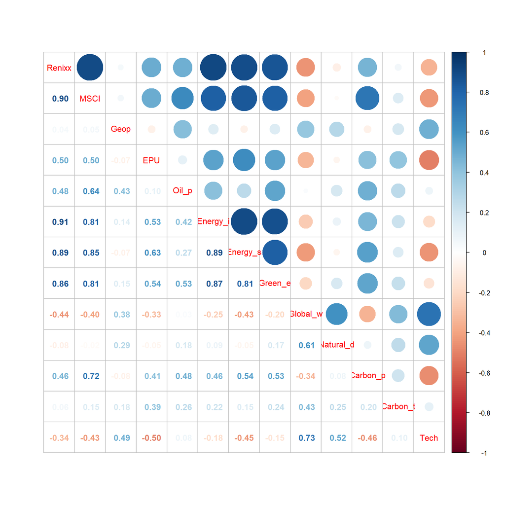

```r
#Correlation plot
corrplot.mixed(cor(data_pred[1:96, 1:13]))
```

```r
#Instantaneous causality
vm = VAR(data_pred[1:96, c(1, 6:8)],
         p = 1,
         type = 'trend',
         season = 12)
causality(vm, cause = "Renixx")
```

```
## $Granger
##
##  Granger causality H0: Renixx do not Granger-cause Energy_i Energy_s
##  Green_e
##
## data:  VAR object vm
## F-Test = 3.1325, df1 = 3, df2 = 316, p-value = 0.02585
##
##
## $Instant
##
##  H0: No instantaneous causality between: Renixx and Energy_i Energy_s
##  Green_e
##
## data:  VAR object vm
## Chi-squared = 6.6, df = 3, p-value = 0.0858
```

```r
#Arima
all_series <- ts(data_pred, start = c(2015, 1), frequency = 12)
for (i in 96:(sample - 1)) {
  arima <- auto.arima(all_series[1:i, c('Renixx')], seasonal = TRUE)
  pred_arima <- forecast::forecast(arima, h = 1)
  predictions_uni[(i - 96 + 1), 1] <- pred_arima$mean
  lower_uni[(i - 96 + 1), 1] <- pred_arima$lower[, 2]
  up_uni[(i - 96 + 1), 1] <- pred_arima$upper[, 2]
}
```

```r
#BSTS
for (i in 96:(sample - 1)) {
  #lag
  (ss <- list())
  ss <- AddAutoAr(ss, data_pred[1:i, c('Renixx')], lags = 1) #p=1 default
  ss <- AddLocalLevel(ss, data_pred[1:i, c('Renixx')])
  ss <- AddSeasonal(ss, data_pred[1:i, c('Renixx')], nseasons = 12)
  bsts.model2 <- bsts(
    data_pred[1:i, c('Renixx')],
    state.specification = ss,
    niter = 1000,
    #number of MCMC draws
    ping = 0,
    seed = 2016,
    expected.model.size = 3
  )
  burn <- SuggestBurn(0.1, bsts.model2) #Suggested burning 0.1
  pred_bayesian2 <-
    predict(
      bsts.model2,
      data_pred[(i + 1), ],
      horizon = 1,
      burn = burn,
      quantiles = c(.025, .975)
    )
  ##Saving
  predictions_uni[(i - 96 + 1), 2] <- pred_bayesian2$mean
  lower_uni[(i - 96 + 1), 2] <- pred_bayesian2$interval[1, ]
  up_uni[(i - 96 + 1), 2] <- pred_bayesian2$interval[2, ]
}
```

```r
#Arimax with lagged values
data_pred2 <-
  cbind(data_pred$Renixx, lag(data_pred[, c(6)]))[2:length(data_pred[, 1]), ] #lagged values to prevent overconfidence
rownames(data_pred2) <- NULL
colnames(data_pred2) <- c('Renixx', 'Energy_i')
all_series <- ts(data_pred2, start = c(2015, 2), frequency = 12)
for (i in (96 - 1):(sample - 1 - 1)) {
  arimax <-
    auto.arima(all_series[1:i, 1], seasonal = TRUE, xreg = all_series[1:i, c('Energy_i')])
  new <- matrix(all_series[(i + 1), c('Energy_i')], ncol = 1)
  colnames(new) <- c('Energy_i')
  pred_arimax <- forecast::forecast(arimax, xreg = new)
  predictions_uni[(i - (96 - 1) + 1), 3] <- pred_arimax$mean
  lower_uni[(i - (96 - 1) + 1), 3] <- pred_arimax$lower[, 2]
  up_uni[(i - (96 - 1) + 1), 3] <- pred_arimax$upper[, 2]
}
```

```r
#Arimax with current values
all_series <- ts(data_pred, start = c(2015, 1), frequency = 12)
for (i in 96:(sample - 1)) {
  x <- matrix(all_series[1:i, c('Green_e', 'Energy_i', 'Energy_s')], ncol =
                3)
  colnames(x) <- c('Green_e', 'Energy_i', 'Energy_s')
  arimax <- auto.arima(all_series[1:i, 1], xreg = x, seasonal = TRUE)
  new <-
    matrix(all_series[(i + 1), c('Green_e', 'Energy_i', 'Energy_s')], ncol =
             3)
  colnames(new) <- c('Green_e', 'Energy_i', 'Energy_s')
  pred_arimax <- forecast::forecast(arimax, xreg = new)
  predictions_uni[(i - 96 + 1), 4] <- pred_arimax$mean
  lower_uni[(i - 96 + 1), 4] <- pred_arimax$lower[, 2]
  up_uni[(i - 96 + 1), 4] <- pred_arimax$upper[, 2]
}
```

```r
#VECM
for (i in 96:(sample - 1)) {
  all_series <-
    ts(data_pred[1:i, c('Renixx', 'Energy_i')], start = c(2015, 1), frequency =
         12)
  #lag order
  var <-
    VARselect(all_series,
              type = "both",
              lag.max = 12,
              season = 12)
  p <- var$selection["FPE(n)"]
  #Estimation of the VAR
  var_all = VAR(all_series, p, season = 12, type = 'both') #3 for cointegration
  #Cointegration test
  nlags = max((p - 1), 2)
  jotest_all = ca.jo(
    all_series,
    type = "eigen",
    K = nlags,
    ecdet = "trend",
    spec = "transitory",
    season = 12
  )
  summary(jotest_all)
  jotest_all = ca.jo(
    all_series,
    type = "trace",
    K = nlags,
    ecdet = "trend",
    spec = "transitory",
    season = 12
  )
  summary(jotest_all)
  #Cointegration level
  print(sum(jotest_all@teststat > jotest_all@cval[, 2]))
  #VECM
  y.VEC <-
    cajorls(jotest_all, r = sum(jotest_all@teststat > jotest_all@cval[, 2]))
  #VECM to VAR
  v0.VAR <-
    vec2var(jotest_all, r = sum(jotest_all@teststat > jotest_all@cval[, 2]))
  #Probability forecasts
  pred_var <- predict(v0.VAR, n.ahead = 1)
  predictions_uni[(i - 96 + 1), 5] <- pred_var$fcst$Renixx[, 1]
  lower_uni[(i - 96 + 1), 5] <- pred_var$fcst$Renixx[, 2]
  up_uni[(i - 96 + 1), 5] <- pred_var$fcst$Renixx[, 3]
}
```

```
## [1] 1
## [1] 1
## [1] 1
## [1] 1
## [1] 1
## [1] 1
## [1] 1
## [1] 1
## [1] 1
## [1] 1
## [1] 1
## [1] 1
```

Below, the metrics of the model are reported, along with some robustness checks.

```r
#SMAPE
Metrics::smape(predictions_uni[, 1], data_pred$Renixx[97:108]) * 100 #by 100 to obtain the percentage
```

```
## [1] 0.7655882
```

```r
Metrics::smape(predictions_uni[, 2], data_pred$Renixx[97:108]) * 100
```

```
## [1] 0.783672
```

```r
Metrics::smape(predictions_uni[, 3], data_pred$Renixx[97:108]) * 100
```

```
## [1] 0.6745161
```

```r
Metrics::smape(predictions_uni[, 4], data_pred$Renixx[97:108]) * 100
```

```
## [1] 0.647688
```

```r
Metrics::smape(predictions_uni[, 5], data_pred$Renixx[97:108]) * 100
```

```
## [1] 0.8236223
```

```r
#RMSE
Metrics::rmse(predictions_uni[, 1], data_pred$Renixx[97:108])
```

```
## [1] 0.066303
```

```r
Metrics::rmse(predictions_uni[, 2], data_pred$Renixx[97:108])
```

```
## [1] 0.07021744
```

```r
Metrics::rmse(predictions_uni[, 3], data_pred$Renixx[97:108])
```

```
## [1] 0.06108089
```

```r
Metrics::rmse(predictions_uni[, 4], data_pred$Renixx[97:108])
```

```
## [1] 0.05979035
```

```r
Metrics::rmse(predictions_uni[, 5], data_pred$Renixx[97:108])
```

```
## [1] 0.07281631
```

```r
#DM test
m <- predictions_uni - data_pred$Renixx[97:108]
#ARIMAX lagged-values
dm.test(m[, 1], m[, 3], alternative =  "greater", h = 1) #h=1 default value of the function
```

```
##
##  Diebold-Mariano Test
##
## data:  m[, 1]m[, 3]
## DM = 1.5967, Forecast horizon = 1, Loss function power = 2, p-value =
## 0.06932
## alternative hypothesis: greater
```

```r
dm.test(m[, 2], m[, 3], alternative =  "greater", h = 1)
```

```
##
##  Diebold-Mariano Test
##
## data:  m[, 2]m[, 3]
## DM = 1.4089, Forecast horizon = 1, Loss function power = 2, p-value =
## 0.09326
## alternative hypothesis: greater
```

```r
dm.test(m[, 4], m[, 3], alternative =  "greater", h = 1)
```

```
##
##  Diebold-Mariano Test
##
## data:  m[, 4]m[, 3]
## DM = -0.25249, Forecast horizon = 1, Loss function power = 2, p-value =
## 0.5973
## alternative hypothesis: greater
```

```r
#ARIMAX actual data
dm.test(m[, 1], m[, 4], alternative =  "greater", h = 1)
```

```
##
##  Diebold-Mariano Test
##
## data:  m[, 1]m[, 4]
## DM = 1.9186, Forecast horizon = 1, Loss function power = 2, p-value =
## 0.04067
## alternative hypothesis: greater
```

```r
dm.test(m[, 2], m[, 4], alternative =  "greater", h = 1)
```

```
##
##  Diebold-Mariano Test
##
## data:  m[, 2]m[, 4]
## DM = 2.2966, Forecast horizon = 1, Loss function power = 2, p-value =
## 0.02114
## alternative hypothesis: greater
```

```r
dm.test(m[, 3], m[, 4], alternative =  "greater", h = 1)
```

```
##
##  Diebold-Mariano Test
##
## data:  m[, 3]m[, 4]
## DM = 0.25249, Forecast horizon = 1, Loss function power = 2, p-value =
## 0.4027
## alternative hypothesis: greater
```

Finally, the results of the best model are plotted below.

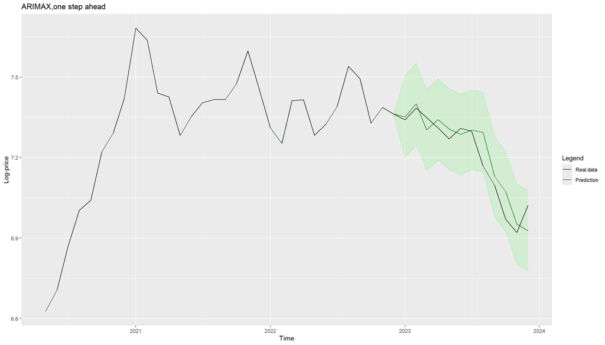

```r
#Plot
ggplot(data_pred[65:sample, ], aes(x = as.Date(Date), y = Renixx), ) +
  geom_line(aes(
    y = c(data_pred$Renixx[65:96], predictions_uni[, 4]),
    color = 'Prediction'
  )) +
  geom_ribbon(
    aes(
      ymin = c(data_pred$Renixx[65:96], lower_uni[, 4]),
      ymax = c(data_pred$Renixx[65:96], up_uni[, 4])
    ),
    alpha = 0.1,
    fill = "green",
    color = "green",
    linetype = "dotted"
  ) +
  geom_line(aes(color = 'Real data')) +
  labs(title = 'ARIMAX,one step ahead') + xlab('Time') + ylab('Log-price') +
  scale_color_manual(
    name = 'Legend',
    breaks = c('Real data', 'Prediction'),
    values = c(
      'Real data' = 'black',
      'Prediction' = 'darkgreen'
    )
  )
```

```r
coeftest(arimax) #ARIMAX model with actual value, last iteration
```

```
##
## z test of coefficients:
##
##            Estimate Std. Error z value  Pr(>|z|)
## ar1        0.985411   0.012647 77.9145 < 2.2e-16 ***
## ma1        0.257106   0.111704  2.3017  0.021354 *
## intercept  5.474900   0.886975  6.1726 6.719e-10 ***
## Green_e    0.144022   0.054700  2.6330  0.008464 **
## Energy_i  -0.137543   0.066089 -2.0812  0.037418 *
## Energy_s   0.069005   0.055530  1.2427  0.213989
## ---
## Signif. codes:  0 '***' 0.001 '**' 0.01 '*' 0.05 '.' 0.1 ' ' 1
```